# Estudios de Informática, Multimedia y Telecomunicaciones

# Minería de datos: PRA1 - Selección y preparación de un juego de datos

Autor: Pablo Suárez

Noviembre 2023

# 1 Enunciado

Todo estudio analítico debe nacer de una necesidad por parte del **negocio** o de una voluntad de dotarle de un conocimiento contenido en los datos y que solo podremos obtener a través de una colección de buenas prácticas basadas en la Minería de Datos.

El mundo de la analítica de datos se sustenta en 3 ejes:

A. Uno de ellos es el profundo **conocimiento** que deberíamos tener **del negocio** al que tratamos de dar respuestas mediante los estudios analíticos.

B. El otro gran eje es sin duda las **capacidades analíticas** que seamos capaces de desplegar y en este sentido, las dos prácticas de esta asignatura pretenden que el estudiante realice un recorrido sólido por este segundo eje.

C. El tercer eje son los **Datos**. Las necesidades del Negocio deben concretarse con preguntas analíticas que a su vez sean viables responder a partir de los datos de que disponemos. La tarea de analizar los datos es sin duda importante, pero la tarea de identificarlos y obtenerlos va a ser para un analista un reto permanente.

Como **primera parte** del estudio analítico que nos disponemos a realizar, se pide al estudiante que complete los siguientes pasos:

1. Plantear un problema de analítica de datos detallando los objetivos analíticos y explica una metodología para resolverlos de acuerdo con lo que se ha practicado en las PEC y lo que se ha aprendido en el material didáctico.
2. Seleccionar un juego de datos y justificar su elección. El juego de datos **deberá tener capacidades** para que se le puedan aplicar **algoritmos supervisados**, **algoritmos no supervisados** y **reglas de asociación** y deberá estar alineado con el problema analítico planteado en el paso anterior.

**Requisito mínimo**: El juego de datos deberá tener como mínimo 500 observaciones con un mínimo de 5 variables numéricas, 2 categóricas y 1 binaria. Además **debe ser distinto**, es importante que no sea un dataset usado en las PEC anteriores.

Adjuntamos aquí una lista de portales de datos abiertos para seleccionar el juego de datos. Se pueden usar otras fuentes para obtener vuestro juego de datos, pero recordad de citarlas:

- **Datos abiertos**
  - [Google Dataset Search](https://datasetsearch.research.google.com/)
  - [Datos abiertos España](https://datos.gob.es/es/catalogo?q=&frequency=%7B%22type%22%3A+%22months%22%2C+%22value%22%3A+%221%22%7D&sort=score+desc%2C+metadata_modified+desc)
  - [Datos abiertos Madrid](https://datos.madrid.es/portal/site/egob/)
  - [Datos abiertos Barcelona](https://opendata-ajuntament.barcelona.cat/es/)
  - [Datos abiertos Londres](https://data.london.gov.uk/)
  - [Datos abiertos New York](https://opendata.cityofnewyork.us/)
- **Conjuntos de datos para aprendizaje automático e investigación**
  - [UCI Machine Learning](https://archive.ics.uci.edu/ml/datasets.php)
  - [Datasets for machine-learning research (Wikipedia)](https://en.wikipedia.org/wiki/List_of_datasets_for_machine-learning_research)
  - [Kaggle datasets](https://www.kaggle.com/datasets)
3. Realizar un análisis exploratorio del juego de datos seleccionado.
4. Realizar tareas de limpieza y acondicionado para poder ser usado en procesos de modelado.
5. Realizar métodos de discretización
6. Aplicar un estudio PCA sobre el juego de datos. A pesar de no estar explicado en el material didáctico, se valorará si en lugar de PCA investigáis por vuestra cuenta y aplicáis SVD (Single Value Decomposition).
- **Algunos recursos**
  - [PCA para reducción de dimensiones](https://www.aprendemachinelearning.com/comprende-principal-component-analysis/)
  - [SVD Singular Value Decomposition](https://web.mit.edu/be.400/www/SVD/Singular_Value_Decomposition.htm)

Recordad que para todas las PRA es **necesario documentar** en cada apartado del ejercicio práctico que se ha hecho, por qué se ha hecho y cómo se ha hecho. Asimismo, todas las decisiones y conclusiones deberán ser presentados de forma razonada y clara, **contextualizando los resultados**, es decir, especificando todos y cada uno de los pasos que se hayan llevado a cabo para su resolución. Por último, incluid una **conclusión final** resumiendo los resultados obtenidos en la práctica e indicad eventuales **citaciones bibliográficas**, fuentes internas/externas y materiales de investigación.

- **Documento entregable**

Solo hay que entregar el documento html y hay que hacerlo con el siguiente nombre 75.584-PRA1-NombreEstudiante.html

# 2 Recursos de programación

- Incluimos en este apartado una lista de recursos de programación para minería de datos donde podréis encontrar ejemplos, ideas e inspiración:
  - [Material adicional del libro: Minería de datos Modelos y Algoritmos](http://oer.uoc.edu/libroMD/)
  - [Espacio de recursos UOC para ciencia de datos](http://datascience.recursos.uoc.edu/es/)
  - [Buscador de código R](https://rseek.org/)
  - [Colección de cheatsheets en R](https://www.rstudio.com/resources/cheatsheets/)

# 3 Solución

## 3.1 Planteamiento

Como se ha podido ver por el enunciado, esta PRA1 se centra en la primera parte de un proyecto típico de minería de datos. Habiendo dicho esto, ahora se comienza con la definición del objetivo analítico.

Los últimos tres meses del año suelen ser meses de muchos cumpleaños y fiestas, por no mencionar las navidades, que poco a poco se van acercando, y con ello el aumento de compras, rebajas, y gastos significativos de dinero. Es por esto, que cada vez más gente opta por adquirir tarjetas de crédito, ya que pemiten pagar en cuotas, ofrecen descuentos, permiten gastos de emergencia (en caso de no tener ahorros) y facilitan el ahorro de dinero en intereses. No obstante, este tipo de tarjetas son un arma de doble filo, ya que favorecen las compras desmedidas y el endeudamiento, así como incrementar la deuda existente, y esto es algo que los bancos quieren evitar a toda costa. Es por esto, que las entidades bancarias, tienen que tener claro a quien pueden darle una tarjeta de crédito, y a quien no. Por lo tanto, el principal objetivo analítico de este estudio, y consecuentemente, el objetivo de este proyecto de minería de datos, es el de predecir si un cliente, es o no apto, para adquirir una tarjeta de crédito, en base a información real y personal, pero no comprometedora que una entidad bancaria ha publicado.

Adicionalmente, con este estudio analítico se pretende dar un paso más grande, definiendo un objetivo más general, pero aun más prometedor: detectar/predecir el fraude. Esto se pretende acometer con la base de datos que se va detallar más adelante. Pero básicamente, si se es capaz de clasificar personas “aptas” y “no aptas”, para obtener una tarjeta de crédito, a partir del *dataset* original y del conocimiento que se ha extraído de él, se podrían detectar comportamientos fraudulentos. Esto es relevante, pues el fraude es algo que afecta a cualquier ámbito del mercado y del sector bancario, puesto que todo tiene un valor y alguien tiene que pagarlo.

Tanto el objetivo de este estudio analítico mencionado antes, como el objetivo posterior (detectar/predecir el fraude) constituyen un plan de beneficio asegurado para los bancos y mercados, pues, conocer quien puede optar a una tarjeta de crédito y quien no puede, así como detectar el fraude, se traduce en pérdidas que el banco puede evitar, o incluso ganancias en diversos ámbitos: dinero, buena fama, confiable, etc. Y por último, estas ganancias, se pueden traducir en confianza por parte de los mercados hacía las entidades bancarias

Como lo que se quiere, es predecir si un perfil de cliente es o no apto para adquirir una tarjeta de crédito, la tarea que se llevará a cabo, será la de clasificación de perfiles de clientes. En este caso, la tarea de clasificación, será de naturaleza binaria, puesto que solo existen dos etiquetas, apto o no apto. Esto que se acaba de decir, se puede definir matemáticamente de la siguiente manera:

Sea $\hat{y}$ la estimación llevada a cabo por el modelo de clasificación binario, esto implica, que por definción, $\hat{y}$ solo tomará dos valores, i.e., $\hat{y} \in [0,1]$ dónde:

- $0 := cliente \hspace{1mm} ``no \hspace{1mm} apto''$
- $1 := cliente \hspace{1mm} ``apto''$

Varios ejemplos de modelos predictivos serían los arboles de decisión y un ejemplo más contemporáneo serían las series temporales construidas por redes neuronales. No obstante, de esto se hablará en etapas posteriores del proyecto.

Este objetivo analítico se centra en intentar asignar una etiqueta, en este caso, “apto” o “no apto”, a un registro caracterizado por un conjunto de variables específicas. A partir de este objetivo analítico se podrían derivar algunos objetivos intermedios que también podrían formar parte de otro proyecto de minería de datos, pero que en este caso, resultan ser imprescindibles para lograr dicho objetivo principal. Estos objetivos son:

- Reconocer factores de riesgo en los clientes/registros (identificar las variables más importantes).
- Medir el impacto/peso de las variables en las tendencias/comportamientos de los registros,
- Clasificación de clientes, o segmentación en grupos, dependiendo de su grado de “idoneidad” para optar a una tarjeta de crédito.
- Tendencia de valores en los distintos atributos

Como se ha visto en teoría, en PECs anteriores y en el caso práctico de este tema, la metodolgía que se va seguir para cumplir con el objetivo analítico principal, y el resto de los antes mencionados, es la siguiente:

- Establecimiento del objetivo analítico y la metodología.
- Selección del juego de datos.
- Verificación del juego de datos.
- Preprocesado de los datos (limpieza y acondicionamiento):
  - Comprobación de errores de escritura.
  - Comprobación de errores en los valores.
  - Comprobación y gestión de valores nulos.
  - Comprobación y gestión de atributos vacíos.
- Análisis exploratorio del juego de datos:
  - Cálculo de medias, medianas.
  - Determinación de correlaciones entre variables y los motivos que las justifican.
  - Determinar las distribuciones de los datos.
  - Normalizar datos.
  - Simplificaciones decimales.
  - Transformaciones de escala.
  - Pasar datos numéricos a categóricos y agrupar valores.
  - Creación de un nuevo atributo.
- Limpieza de datos
- Implementación de técnicas de discretización.
- Aplicación de técnicas PCA y SVD en el juego de datos.

Cabe destacar, que dependiendo de las calidad del juego de datos, habrá pasos de la metodología que no serán necesarios.

Habiendo explicado el objetivo analítico principal y el resto de objetivos, así como la metodología que se pretende seguir, se podrían definir las métricas que nos van a ayudar a determinar el grado de cumplimiento del objetivo analítico. A voz de pronto, la pimera métrica que nos viene a la cabeza es la precisión, y como el proyecto lo voy a desarrollar yo, diría que una precisión a partir del 75% sería razonable, dependiendo del número de variables que el modelo de clasificación tenga en cuenta claro. No obstante, considero que es muy pronto para determinar la precicisión mínima, sin explorado ni siquiera el *dataset*

Otra métrica interesante es la exactitud, que se define como el número de muestras para las que el modelo ha predicho bien su clase, frente al número total de muestras.

En el caso de que a lo largo del proyecto de minería de datos, haya un desbalance de clases, la métrica de la exactitud, podría arrojar resultados confusos, es por esto, que si se diese el caso de un desbalance de clases, se podrían tener en cuenta las métricas de **TP** (*True Positive*), **FP** (*False Positive*), **TN** (*True Negative*), **FN** (*False Negative*).

## 3.2 Selección del juego de datos

El juego de datos utilizado en este estudio analítico se corresponde con la información personal de un conjunto de candidatos interesados en obtener una tarjeta de crédito. A partir de esta información se va a determinar que candidatos son o no aptos para obtener una tarjeta de crédito. El juego de datos puede encontrarse [aquí](https://www.kaggle.com/datasets/rikdifos/credit-card-approval-prediction/data).

Se ha seleccionado este *dataset* debido a su gran variedad en cuanto a tipos de variables, que pueden ayudar en el estudio analítico. No obstante, como en cualquier proyecto de minería de datos, habrá variables que no se usarán o que deberán de ser eliminadas, en caso de no aportar conocimiento o contaminar el ya obtenido.

El *dataset* está compuesto por 438558 registros, y 18 variables, las 18 variables se detallan a continuación:

- **ID**: el identificador de cliente.
- **CODE_GENDER**: género. “M” *male*, “F” *female*.
- **FLAG_OWN_CAR**: ¿tiene coche? “Y” *yes,* “N” *no*
- **FLAG_OWN_REALTY**: ¿tiene propiedad? “Y” *yes,* “N” *no*
- **CNT_CHILDREN**: número de hijos. $\mathbb{R}_+$
- **AMT_INCOME_TOTAL**: salario anual. $\mathbb{R}_+$
- **NAME_INCOME_TYPE**: categoria salarial.
- **NAME_EDUCATION_TYPE**: nivel educativo.
- **NAME_FAMILY_STATUS**: estado civil.
- **NAME_HOUSING_TYPE**: tipo de casa.
- **DAYS_BIRTH**: cumpleaños (cuenta hacia atrás) e.g., “0” cumpleaños es el día actual, “-1” el cumpleaños fue ayer, “-14” el cumpleaños fue hace dos semanas. $[\mathbb{R}_{-},0]$
- **DAYS_EMPLOYED**: número de días empleado (cuenta hacia atrás) e.g., si el número de días es positivo, quiere decir que la persona está desempleada. $\mathbb{R}_{\pm}$
- **FLAG_MOBIL**: ¿tiene teléfono móvil? $[0,1]$
- **FLAG_WORK_PHONE**: ¿tiene teléfono móvil de trabajo? $[0,1]$
- **FLAG_PHONE**: ¿tiene teléfono? $[0,1]$
- **FLAG_EMAIL**: ¿tiene correo electrónico? $[0,1]$
- **OCCUPATION_TYPE**: ocupación.
- **CNT_FAM_MEMBERS**: número de integrantes del núcleo familiar. $\mathbb{R}_+$

Esperemos no tener problemas al tratar con los datos, ya que es una cantidad ingente de resgistros (438558).

Por último, cabe destacar que el *dataset* elegido, en principio, solo se contempla para detectar si un cliente es o no apto para optar a una tarjeta de crédito. No obstante, con la adición de registros externos y variables adicionales, se podría expandir el horizonte de objetivos analíticos, para perseguir otros obejtivos con el *dataset*, aunque para el objetivo relacionado con el fraude, el *dataset* original, debería de ser suficiente.

Por último, mencionar que este *dataset* puede ser objeto de modelos supervisados (con etiquetas, i.e., se conoce el resultado) y no supervisados (sin etiquetas, i.e., principalmente para la búsqueda de características). Importante, aunque en el propio dataset no haya una variable/columna binaria, que muestre, si el candidato es apto o no a optar a una tarjeta de crédito, dentro del zip del *datset* que se ha descargado, hay otro dataset llamado “credit_record.csv” que puede resolver este problema y que tiene las siguientes variables (columnas):

- **ID**: el identificador de cliente
- **MONTHS_BALANCE**: en este caso, el mes de los datos extraídos es el punto de partida, hacia atrás, 0 es el mes actual, -1 es el mes anterior, y así sucesivamente
- **STATUS**
  - “0”: 1-29 días de demora.
  - “1”: 30-59 días de demora.
  - “2”: 60-89 días de demora.
  - “3”: 90-119 días de demora.
  - “4”: 120-149 días de demora.
  - “5”: Deudas vencibles o incobrables, cancelaciones de más de 150 días.
  - “C”: Cancelado ese mes.
  - “X”: Sin préstamo este mes.

Cada fila representa la condición de un cliente en diferentes meses, por lo que es una tabla extremadamente larga (ver este enlace: [discusion del dataset](https://www.kaggle.com/datasets/rikdifos/credit-card-approval-prediction/discussion/119320))

Este *dataset* tiene múltiples filas de información de cada candidato del *dataset* “application_record.csv” a cerca de su estado financiero. Por lo tanto, a fin de poder aplicar un modelo supervisado en el futuro *dataset* “application_record.csv” (una vez limpio y acondicionado) se podría crear una columna “apto o no apto” que contenga o 1s o 0s, dependiendo de si, en alguno de los históricos de cada uno de los candidatos que se muestran en “credit_record.csv” aparecen muchos “4s” o un “5” o una “C” en la variable “STATUS” (por lo tanto 0: no apto). Por último, esta nueva columa, se exportaría al *dataset* “application_record.csv” final.

Otro criterio, para generar que el propio autor ofrece, es el de llevar a cabo un “analisis de antigüedad, del inglés: *“Vintage Analysis”* con los dos *datasets*. Este tipo de analisis es ampliamente conocido y muy utilizado para gestionar el riesgo de crédito, que ilustra el comportamiento financiero de un cliente tras la apertura de su cuenta. Basándose en el mismo periodo de apertura, este analisis permite calcular el ratio de impago de una cartera de préstamos (véase más información de esto aquí: [EDA & Vintage Analysis](https://www.kaggle.com/code/rikdifos/eda-vintage-analysis/notebook))

Este criterio que aplicaré a la hora de querer aplicar el modelo, se ha tomado en base a la lógica y a la siguiente referencia de BBVA Argentina: [BBVA](https://www.bbva.com.ar/economia-para-tu-dia-a-dia/ef/tarjeta-de-credito/tarjeta-de-credito-con-veraz-en-argentina.html#:~:text=Con%20un%20Veraz%20negativo%20vigente,de%20cr%C3%A9dito%20a%20su%20medida.).

## 3.3 Análisis exploratorio del juego de datos, limpieza y acondicionado

Primero se cargan todas las librerías que podrían necesitarse a lo largo del estudio:

```r
# install.packages("magrittr") # package installations are only needed the first time you use it
# install.packages("dplyr")    # alternative installation of the %>%
library(magrittr) # needs to be run every time you start R and want to use %>%
library(dplyr)    # alternatively, this also loads %>%
```

Conocidas las variables de cada uno de los registros, ahora se procede a exportar el csv para empezar a explorar más en profundidad el juego de datos:

```r
nombre_archivo = 'application_record.CSV'
df_original <- read.csv(nombre_archivo)
structure = str(df_original)
```

```
## 'data.frame':    438557 obs. of  18 variables:
##  $ ID                 : int  5008804 5008805 5008806 5008808 5008809 5008810 5008811 5008812 5008813 5008814 ...
##  $ CODE_GENDER        : chr  "M" "M" "M" "F" ...
##  $ FLAG_OWN_CAR       : chr  "Y" "Y" "Y" "N" ...
##  $ FLAG_OWN_REALTY    : chr  "Y" "Y" "Y" "Y" ...
##  $ CNT_CHILDREN       : int  0 0 0 0 0 0 0 0 0 0 ...
##  $ AMT_INCOME_TOTAL   : num  427500 427500 112500 270000 270000 ...
##  $ NAME_INCOME_TYPE   : chr  "Working" "Working" "Working" "Commercial associate" ...
##  $ NAME_EDUCATION_TYPE: chr  "Higher education" "Higher education" "Secondary / secondary special" "Secondary / secondary special" ...
##  $ NAME_FAMILY_STATUS : chr  "Civil marriage" "Civil marriage" "Married" "Single / not married" ...
##  $ NAME_HOUSING_TYPE  : chr  "Rented apartment" "Rented apartment" "House / apartment" "House / apartment" ...
##  $ DAYS_BIRTH         : int  -12005 -12005 -21474 -19110 -19110 -19110 -19110 -22464 -22464 -22464 ...
##  $ DAYS_EMPLOYED      : int  -4542 -4542 -1134 -3051 -3051 -3051 -3051 365243 365243 365243 ...
##  $ FLAG_MOBIL         : int  1 1 1 1 1 1 1 1 1 1 ...
##  $ FLAG_WORK_PHONE    : int  1 1 0 0 0 0 0 0 0 0 ...
##  $ FLAG_PHONE         : int  0 0 0 1 1 1 1 0 0 0 ...
##  $ FLAG_EMAIL         : int  0 0 0 1 1 1 1 0 0 0 ...
##  $ OCCUPATION_TYPE    : chr  "" "" "Security staff" "Sales staff" ...
##  $ CNT_FAM_MEMBERS    : num  2 2 2 1 1 1 1 1 1 1 ...
```

Como se puede ver, hay 8 variables de tipo “int”, 8 variables de tipo “chr” y dos variables de tipo “num”. Esto significa que se están cumpliendo los requisitos enunciados en el punto 2 del enunciado, relativos al *dataset*, pues además se sabe, que hay más de 500 registros. No obstante, ahora se va a ver gráficamente esta propoción que se acaba de dar:

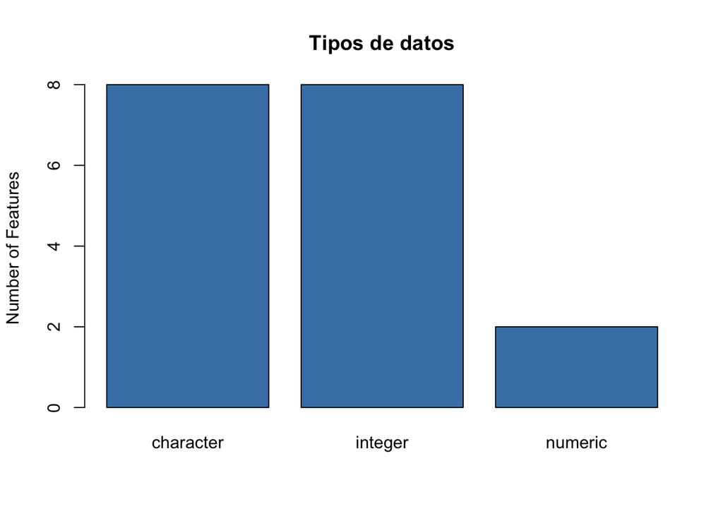

```r
tipos_de_datos <- function(df_original) {
  res <- lapply(df_original, class)
  res_frame <- data.frame(unlist(res))
  barplot(table(res_frame), main="Tipos de datos", col="steelblue", ylab="Number of Features")
}

tipos_de_datos(df_original)
```

Ahora se visualizan las primeras y últimas filas del juego de datos

```r
head(df_original)
```

```
##        ID CODE_GENDER FLAG_OWN_CAR FLAG_OWN_REALTY CNT_CHILDREN
## 1 5008804           M            Y               Y            0
## 2 5008805           M            Y               Y            0
## 3 5008806           M            Y               Y            0
## 4 5008808           F            N               Y            0
## 5 5008809           F            N               Y            0
## 6 5008810           F            N               Y            0
##   AMT_INCOME_TOTAL     NAME_INCOME_TYPE           NAME_EDUCATION_TYPE
## 1           427500              Working              Higher education
## 2           427500              Working              Higher education
## 3           112500              Working Secondary / secondary special
## 4           270000 Commercial associate Secondary / secondary special
## 5           270000 Commercial associate Secondary / secondary special
## 6           270000 Commercial associate Secondary / secondary special
##     NAME_FAMILY_STATUS NAME_HOUSING_TYPE DAYS_BIRTH DAYS_EMPLOYED FLAG_MOBIL
## 1       Civil marriage  Rented apartment     -12005         -4542          1
## 2       Civil marriage  Rented apartment     -12005         -4542          1
## 3              Married House / apartment     -21474         -1134          1
## 4 Single / not married House / apartment     -19110         -3051          1
## 5 Single / not married House / apartment     -19110         -3051          1
## 6 Single / not married House / apartment     -19110         -3051          1
##   FLAG_WORK_PHONE FLAG_PHONE FLAG_EMAIL OCCUPATION_TYPE CNT_FAM_MEMBERS
## 1               1          0          0                               2
## 2               1          0          0                               2
## 3               0          0          0  Security staff               2
## 4               0          1          1     Sales staff               1
## 5               0          1          1     Sales staff               1
## 6               0          1          1     Sales staff               1
```

```r
tail(df_original)
```

```
##             ID CODE_GENDER FLAG_OWN_CAR FLAG_OWN_REALTY CNT_CHILDREN
## 438552 6840102           F            N               Y            0
## 438553 6840104           M            N               Y            0
## 438554 6840222           F            N               N            0
## 438555 6841878           F            N               N            0
## 438556 6842765           F            N               Y            0
## 438557 6842885           F            N               Y            0
##        AMT_INCOME_TOTAL     NAME_INCOME_TYPE           NAME_EDUCATION_TYPE
## 438552           135000            Pensioner Secondary / secondary special
## 438553           135000            Pensioner Secondary / secondary special
## 438554           103500              Working Secondary / secondary special
## 438555            54000 Commercial associate              Higher education
## 438556            72000            Pensioner Secondary / secondary special
## 438557           121500              Working Secondary / secondary special
##          NAME_FAMILY_STATUS NAME_HOUSING_TYPE DAYS_BIRTH DAYS_EMPLOYED
```

[output cut: 20 more lines]

Oficialmente, el juego de datos con el que vamos a tratar, tiene 438557 filas.

Ahora se van a comprobar si hay valores NULOS o vacíos en cada uno de los registros. Primero se comienza con los valores NULOS:

```r
print("Valores NULOS dentro del df_original")
```

```
## [1] "Valores NULOS dentro del df_original"
```

```r
colSums(is.na(df_original))
```

```
##                  ID         CODE_GENDER        FLAG_OWN_CAR     FLAG_OWN_REALTY
##                   0                   0                   0                   0
##        CNT_CHILDREN    AMT_INCOME_TOTAL    NAME_INCOME_TYPE NAME_EDUCATION_TYPE
##                   0                   0                   0                   0
##  NAME_FAMILY_STATUS   NAME_HOUSING_TYPE          DAYS_BIRTH       DAYS_EMPLOYED
##                   0                   0                   0                   0
##          FLAG_MOBIL     FLAG_WORK_PHONE          FLAG_PHONE          FLAG_EMAIL
##                   0                   0                   0                   0
##     OCCUPATION_TYPE     CNT_FAM_MEMBERS
##                   0                   0
```

Como se puede comprobar, no hay ningún valor nulo en el *dataframe*. Ahora pasamos a comprobar si hay valores vacíos:

```r
print("Valores vacíos dentro del df_original")
```

```
## [1] "Valores vacíos dentro del df_original"
```

```r
colSums(df_original == '')
```

```
##                  ID         CODE_GENDER        FLAG_OWN_CAR     FLAG_OWN_REALTY
##                   0                   0                   0                   0
##        CNT_CHILDREN    AMT_INCOME_TOTAL    NAME_INCOME_TYPE NAME_EDUCATION_TYPE
##                   0                   0                   0                   0
##  NAME_FAMILY_STATUS   NAME_HOUSING_TYPE          DAYS_BIRTH       DAYS_EMPLOYED
##                   0                   0                   0                   0
##          FLAG_MOBIL     FLAG_WORK_PHONE          FLAG_PHONE          FLAG_EMAIL
##                   0                   0                   0                   0
##     OCCUPATION_TYPE     CNT_FAM_MEMBERS
##              134203                   0
```

```r
#Cálculo del porcentaje de registros con una celda vacía respecto al total
print(134203*100/438557) # Es una simple regla de tres
```

```
## [1] 30.60104
```

Como bien se puede ver, 17/18 variables cuentan con todas sus celdas pobladas, a excepción de la variable “OCCUPATION_TYPE”, esta variable es de tipo chr, y refleja el tipo de empleo que tienen cada uno de los candidatos, y por lo tanto, es una variable que puede ofrecer información interesante. La falta de 134203 valores en esta variable, es algo considerable si se estudia de manera aislada, pero además, proporcionalmente, tiene una gran repercusión en el juego de datos, pues la falta de 134203 valores de esa variable, se traduce en una pérdida del 30’6% de valores (en caso de eliminar todos los registros asociados a dichos valores). Por lo tanto, se va a calcular el número de veces que cada uno de los posibles valores que puede tomar esta variable, aparece en el juego de datos:

```r
a = table(df_original['OCCUPATION_TYPE'])
print(a)
```

```
## OCCUPATION_TYPE
##                                 Accountants        Cleaning staff
##                134203                 15985                  5845
##         Cooking staff            Core staff               Drivers
##                  8076                 43007                 26090
## High skill tech staff              HR staff              IT staff
##                 17289                   774                   604
##              Laborers    Low-skill Laborers              Managers
##                 78240                  2140                 35487
##        Medicine staff Private service staff         Realty agents
##                 13520                  3456                  1041
##           Sales staff           Secretaries        Security staff
##                 41098                  2044                  7993
##  Waiters/barmen staff
##                  1665
```

Como se puede ver, hay una gran variedad de empleos, no obstante, el valor que mas se repite es el de ““, esto significa que hay más celdas que están vacías que ninguna otra celda con otro valor. Ahora, se van a eliminar las celdas vacías y se va a intentar transformar los distintos empleos en variables numéricas, para intentar hacer una media (después del siguiente chunk veremos porque)

```r
df_mod <- df_original[apply(df_original != "", 1, all), ]
head(df_mod)
```

```
##         ID CODE_GENDER FLAG_OWN_CAR FLAG_OWN_REALTY CNT_CHILDREN
## 3  5008806           M            Y               Y            0
## 4  5008808           F            N               Y            0
## 5  5008809           F            N               Y            0
## 6  5008810           F            N               Y            0
## 7  5008811           F            N               Y            0
## 11 5008815           M            Y               Y            0
##    AMT_INCOME_TOTAL     NAME_INCOME_TYPE           NAME_EDUCATION_TYPE
## 3            112500              Working Secondary / secondary special
## 4            270000 Commercial associate Secondary / secondary special
## 5            270000 Commercial associate Secondary / secondary special
## 6            270000 Commercial associate Secondary / secondary special
## 7            270000 Commercial associate Secondary / secondary special
## 11           270000              Working              Higher education
##      NAME_FAMILY_STATUS NAME_HOUSING_TYPE DAYS_BIRTH DAYS_EMPLOYED FLAG_MOBIL
## 3               Married House / apartment     -21474         -1134          1
## 4  Single / not married House / apartment     -19110         -3051          1
## 5  Single / not married House / apartment     -19110         -3051          1
## 6  Single / not married House / apartment     -19110         -3051          1
## 7  Single / not married House / apartment     -19110         -3051          1
## 11              Married House / apartment     -16872          -769          1
##    FLAG_WORK_PHONE FLAG_PHONE FLAG_EMAIL OCCUPATION_TYPE CNT_FAM_MEMBERS
## 3                0          0          0  Security staff               2
## 4                0          1          1     Sales staff               1
## 5                0          1          1     Sales staff               1
## 6                0          1          1     Sales staff               1
## 7                0          1          1     Sales staff               1
## 11               1          1          1     Accountants               2
```

```r
tail(df_mod)
```

```
##             ID CODE_GENDER FLAG_OWN_CAR FLAG_OWN_REALTY CNT_CHILDREN
## 438540 6837454           M            Y               Y            1
## 438542 6837707           M            N               Y            0
## 438549 6839936           M            Y               Y            1
## 438554 6840222           F            N               N            0
## 438555 6841878           F            N               N            0
## 438557 6842885           F            N               Y            0
##        AMT_INCOME_TOTAL     NAME_INCOME_TYPE           NAME_EDUCATION_TYPE
## 438540           162000        State servant Secondary / secondary special
## 438542           202500              Working              Higher education
## 438549           135000              Working Secondary / secondary special
## 438554           103500              Working Secondary / secondary special
## 438555            54000 Commercial associate              Higher education
## 438557           121500              Working Secondary / secondary special
##          NAME_FAMILY_STATUS NAME_HOUSING_TYPE DAYS_BIRTH DAYS_EMPLOYED
```

[output cut: 20 more lines]

```r
#Ahora que se han eliminado los registros con columnas vacías, ahora se calcula la media de valores de la variable OCCUPATION_TYPE
a <- table(df_mod['OCCUPATION_TYPE'])
print(head(a))
```

```
## OCCUPATION_TYPE
##           Accountants        Cleaning staff         Cooking staff
##                 15985                  5845                  8076
##            Core staff               Drivers High skill tech staff
##                 43007                 26090                 17289
```

```r
print(head(as.numeric(df_mod$OCCUPATION_TYPE)))
```

```
## [1] NA NA NA NA NA NA
```

Como puede verse arriba, transformar valores de tipo string a valores numéricos, no sale bien. A continuación se explica porque se quería hacer esto.

En este caso hay dos opciones a tener en cuenta para resolver este problema:

- Como faltan 134203 valores, se puede optar por eliminar esos registros enteros.
- Se podrían poblar las celdas vacías con el empleo más común, pues no se puede calcular la media de variables de tipo string (de hecho se ha probado a pasar a numérico los empleos, pero ha dado error. Esto puede verse arriba)

Teniendo en cuenta las dos opciones de arriba, hay que recordar, que una de los aspectos más importantes de un proyecto de minería de datos es el de trbajar inteligente y eficientemente. Es por esto, que aunque la segunda opción, es menos intrusiva y algo más conservadora (se conservan todos esos registros pero con nuevos empleos metidos por nosotros), la primera puede resultar más eficiente e inteligente, por dos motivos. El primero y más relevante, es la cantidad de registros. El juego de datos tiene 438557 filas, lo que se traduce en mucha información, que puede ralentizar el proceso de análisis sin añadir conocimiento (esto es una posibilidad). El segundo motivo tiene que ver con los valores que se le meterían a cada una de las posiciones vacías de dicha variable, ya que rellenar casi el 31% del total, con el empleo más común no es algo que me resulte correcto, de cara a la aplicación del modelo clasificatorio. Por lo que considero que es más oportuno, tener un 31% de filas menos, que rellenar el 31% de los datos con el empleo que más ocurrencia tiene.

Como se ha optado por la primera opción, de ahora en adelante, se va a hacer uso del *dataset* que no tiene celdas vacías, eliminando los registros con alguna celda vacía.

Volviendo a la exploración general de los datos, ahora se van a calcular las estadísticas básicas de cada una de las características del juego. Esto puede verse en el siguiente *chunk* de código.

```r
summary(df_mod)
```

```
##        ID          CODE_GENDER        FLAG_OWN_CAR       FLAG_OWN_REALTY
##  Min.   :5008806   Length:304354      Length:304354      Length:304354
##  1st Qu.:5617726   Class :character   Class :character   Class :character
##  Median :6047822   Mode  :character   Mode  :character   Mode  :character
##  Mean   :6022984
##  3rd Qu.:6449036
##  Max.   :7999952
##   CNT_CHILDREN    AMT_INCOME_TOTAL  NAME_INCOME_TYPE   NAME_EDUCATION_TYPE
##  Min.   : 0.000   Min.   :  27000   Length:304354      Length:304354
##  1st Qu.: 0.000   1st Qu.: 135000   Class :character   Class :character
##  Median : 0.000   Median : 180000   Mode  :character   Mode  :character
##  Mean   : 0.511   Mean   : 194868
##  3rd Qu.: 1.000   3rd Qu.: 225000
##  Max.   :19.000   Max.   :6750000
##  NAME_FAMILY_STATUS NAME_HOUSING_TYPE    DAYS_BIRTH     DAYS_EMPLOYED
##  Length:304354      Length:304354      Min.   :-24770   Min.   :-17531
##  Class :character   Class :character   1st Qu.:-17439   1st Qu.: -3508
##  Mode  :character   Mode  :character   Median :-14583   Median : -1917
##                                        Mean   :-14807   Mean   : -2622
##                                        3rd Qu.:-11944   3rd Qu.:  -919
##                                        Max.   : -7489   Max.   :   -12
##    FLAG_MOBIL FLAG_WORK_PHONE    FLAG_PHONE       FLAG_EMAIL
##  Min.   :1    Min.   :0.0000   Min.   :0.0000   Min.   :0.0000
##  1st Qu.:1    1st Qu.:0.0000   1st Qu.:0.0000   1st Qu.:0.0000
##  Median :1    Median :0.0000   Median :0.0000   Median :0.0000
##  Mean   :1    Mean   :0.2482   Mean   :0.2856   Mean   :0.1175
##  3rd Qu.:1    3rd Qu.:0.0000   3rd Qu.:1.0000   3rd Qu.:0.0000
##  Max.   :1    Max.   :1.0000   Max.   :1.0000   Max.   :1.0000
##  OCCUPATION_TYPE    CNT_FAM_MEMBERS
##  Length:304354      Min.   : 1.000
##  Class :character   1st Qu.: 2.000
##  Mode  :character   Median : 2.000
##                     Mean   : 2.298
##                     3rd Qu.: 3.000
##                     Max.   :20.000
```

De este resultado, se observan los siguientes aspectos:

- Al eliminar el 30.6% del total de datos, ahora se cuentan con 304354 registros (438557-134203).
- Las variables/características de tipo “str” no arrojan datos estadísiticos, pues no son enteros. Habría que estudiar los posibles valores de estas y sus ocurrencias. Seguramente en el siguiente apartado pude que se transformen a variables enteras o binarias, dependiendo de su relevancia en el caso de estudio, y del número de valores que puedan tomar.
- Se podría calcular el valor absoluto de las variables “DAYS_BIRTH” y “DAYS_EMPLOYED” de cara a una mayor facilidad para procesarlas y relacionarlas con el resto de variables (sobretodo a la hora de diseñar un gráfico con ellas, para evitar el eje negativo)
- La variable “FLAG_MOBIL” no aporta información y tampoco va a aportar conocimiento, porque siempre toma el 1 como valor, por lo tanto, en caso de no añadir más registros al *dataset* en el futuro, esta variable podría eliminarse.
- Respecto a la variable “CNT_CHILDREN”, esta muestra como el número máximo de hijos que tiene un candidato, es de 19, pero luego la media de hijos, es de 0.511. Esto es algo bastante sorprendente, pues me esperaba que el número medio de hijos fuese 1 o 2. Por lo que puede ser que ese 19 sea un *outlier*. No obstante, si en la columna “CNT_FAM_MEMBERS” aparecen 20 familiares, significa que el dato es real, pero, este registro podría confundir al modelo de clasificación, al tener un valor tan extremo.
- Respecto al salario anual de los candidatos, i.e., “AMT_INCOME_TOTAL”, puede verse como el salario máximo es de 6750000$, mientras que el mínimo es de 27000$, mientras que el salario medio está en unos 194868$
- Observando la variable “CNT_FAM_MEMBERS” se observa como el número medio de integrantes del núcleo familiar es de 2.298 personas, por lo que parecen predominar las parejas sin hijos, pues la variable “CNT_CHILDREN” muestra que de media hay 0.5 hijos por familia. Además, curiosamente, el candidato que tenía 19 hijos parece estar sol@, pues la variable “CNT_FAM_MEMBERS” indica que el máximo número de integrantes familiares es de 20 personas (19+1).
- Por útltimo, las variables “FLAG_WORK_PHONE”, “FLAG_PHONE” y “FLAG_EMAIL” muestran como, de media, los candidatos no suelen tener tener teléfono de trabajo, ni teléfono fijo, ni correo electrónico correspondientemente. Esto se debe a que sus medias son: 0.2482, 0.2856 y 0.1175 respectivamente.
- La variable “ID” es el identificador del candidato en la base de datos del banco. No obstante, esta variable, no aporta mucha información, por lo tanto se podría eliminar, pues como referencia ya se tiene el índice que ocupa el registro/candidato en la tabla.

Como se ha podido comprobar antes, la variable “FLAG_MOBIL” no aporta información, es por esto que esta columna se elimina del juego de datos a continuación:

```r
table(df_mod$FLAG_MOBIL)
```

```
##
##      1
## 304354
```

```r
drop <- c("FLAG_MOBIL")
df_mod = df_mod[,!(names(df_mod) %in% drop)]
sort(colnames(df_mod)) #COMPROBAMOS QUE LO HEMOS ELIMINADO
```

```
##  [1] "AMT_INCOME_TOTAL"    "CNT_CHILDREN"        "CNT_FAM_MEMBERS"
##  [4] "CODE_GENDER"         "DAYS_BIRTH"          "DAYS_EMPLOYED"
##  [7] "FLAG_EMAIL"          "FLAG_OWN_CAR"        "FLAG_OWN_REALTY"
## [10] "FLAG_PHONE"          "FLAG_WORK_PHONE"     "ID"
## [13] "NAME_EDUCATION_TYPE" "NAME_FAMILY_STATUS"  "NAME_HOUSING_TYPE"
## [16] "NAME_INCOME_TYPE"    "OCCUPATION_TYPE"
```

Ahora se va a comprobar si existen registros duplicados, para ello, comparo todas las columnas del *dataframe* sin tener en cuenta la columna “ID” porque si se tiene en cuenta la columna “ID” en dicha comparación, no se eliminaría ninguna columna, porque ningún ID se repite, y por lo tanto ninguna fila tendría todas sus columnas iguales respecto al resto de filas. No obstante, la columna ID no se está eliminando, ya que en el futuro (segunda PAC) se pretenden añadir las etiquetas a partir del otro *dataframe* (“credit_record.csv”), y esto solo se pude hacer a partir del ID de los candidatos, por eso hay que mantener dicha columna.

```r
df_sin_duplicados <- df_mod[!duplicated(df_mod[, -1]) & !duplicated(df_mod[, -1]), ] #Con el -1 indico que no quiero coger la columna de los IDs porque ningun ID se repite
head(df_sin_duplicados)
```

```
##         ID CODE_GENDER FLAG_OWN_CAR FLAG_OWN_REALTY CNT_CHILDREN
## 3  5008806           M            Y               Y            0
## 4  5008808           F            N               Y            0
## 11 5008815           M            Y               Y            0
## 14 5008819           M            Y               Y            0
## 20 5008825           F            Y               N            0
## 22 5008830           F            N               Y            0
##    AMT_INCOME_TOTAL     NAME_INCOME_TYPE           NAME_EDUCATION_TYPE
## 3            112500              Working Secondary / secondary special
## 4            270000 Commercial associate Secondary / secondary special
## 11           270000              Working              Higher education
## 14           135000 Commercial associate Secondary / secondary special
## 20           130500              Working             Incomplete higher
## 22           157500              Working Secondary / secondary special
##      NAME_FAMILY_STATUS NAME_HOUSING_TYPE DAYS_BIRTH DAYS_EMPLOYED
## 3               Married House / apartment     -21474         -1134
## 4  Single / not married House / apartment     -19110         -3051
## 11              Married House / apartment     -16872          -769
## 14              Married House / apartment     -17778         -1194
## 20              Married House / apartment     -10669         -1103
## 22              Married House / apartment     -10031         -1469
##    FLAG_WORK_PHONE FLAG_PHONE FLAG_EMAIL OCCUPATION_TYPE CNT_FAM_MEMBERS
## 3                0          0          0  Security staff               2
## 4                0          1          1     Sales staff               1
## 11               1          1          1     Accountants               2
## 14               0          0          0        Laborers               2
## 20               0          0          0     Accountants               2
## 22               0          1          0        Laborers               2
```

```r
#print(df_sin_duplicados)
```

```r
print(304354-62608)
```

```
## [1] 241746
```

Como se puede observar, ahora se ha pasado de tener 304354 registros, a tener 62608 registros.

En este punto del proyecto, ya no hay registros duplicados, ni tampoco hay valores vacíos, asi como tampoco valores nulos. Es por esto que a continuación se va a continuar con la exploración de los datos, pero con la perspectiva de obtener conocimiento a partir del conjunto de datos limpios.

Ahora se van a reresentar los valores que pueden tomar cada una de las variables (excepto las variables relacionadas con dinero o cantidades que no son binarias) las varianzas e histogramas de las 4 variables más interesantes. De entre todas las variables del *dataset* principal (i.e., “application_record.csv”) , las variables que resultan más atractivas para este primer estudio, por el tipo de dato que pueden tomar como valor, así como por lo que representan, son: **“AMT_INCOME_TOTAL”**, **“CNT_CHILDREN”**, **“NAME_EDUCATION_TYPE”** y **“FLAG_OWN_REALTY”**.

```r
#Ahora se obtienen los posibles valores de cada una las 4 variables:
#table(df_sin_duplicados$AMT_INCOME_TOTAL)
print('Estos son los valores de la cantidad de hijos y sus ocurrencias')
```

```
## [1] "Estos son los valores de la cantidad de hijos y sus ocurrencias"
```

```r
table(df_sin_duplicados$CNT_CHILDREN)
```

```
##
##     0     1     2     3     4     5     7     9    12    14    19
## 39842 14967  6791   894    86    22     2     1     1     1     1
```

```r
print('Estos son los niveles de educación de los candidatos y sus ocurrencias')
```

```
## [1] "Estos son los niveles de educación de los candidatos y sus ocurrencias"
```

```r
table(df_sin_duplicados$NAME_EDUCATION_TYPE)
```

```
##
##               Academic degree              Higher education
##                            35                         16244
##             Incomplete higher               Lower secondary
##                          2413                           518
## Secondary / secondary special
##                         43398
```

```r
print('Este es el número de gente con y sin propiedad y sus ocurrencias')
```

```
## [1] "Este es el número de gente con y sin propiedad y sus ocurrencias"
```

```r
table(df_sin_duplicados$FLAG_OWN_REALTY)
```

```
##
##     N     Y
## 20195 42413
```

```r
print('Estos son los tipos de casas y sus ocurrencias')
```

```
## [1] "Estos son los tipos de casas y sus ocurrencias"
```

```r
table(df_sin_duplicados$NAME_HOUSING_TYPE)
```

```
##
##     Co-op apartment   House / apartment Municipal apartment    Office apartment
##                 230               55087                2149                 592
##    Rented apartment        With parents
##                1123                3427
```

```r
print('Estos son el número de mujeres y hombres y sus ocurrencias')
```

```
## [1] "Estos son el número de mujeres y hombres y sus ocurrencias"
```

```r
table(df_sin_duplicados$CODE_GENDER)
```

```
##
##     F     M
## 37727 24881
```

```r
print('Estos son los tipos de familias y sus ocurrencias')
```

```
## [1] "Estos son los tipos de familias y sus ocurrencias"
```

```r
table(df_sin_duplicados$NAME_FAMILY_STATUS)
```

```
##
##       Civil marriage              Married            Separated
##                 5956                42357                 3715
## Single / not married                Widow
##                 9217                 1363
```

```r
print('Estos son los tipos de trabajos y sus ocurrencias')
```

```
## [1] "Estos son los tipos de trabajos y sus ocurrencias"
```

```r
table(df_sin_duplicados$NAME_INCOME_TYPE)
```

```
##
## Commercial associate            Pensioner        State servant
##                17569                  125                 5511
##              Student              Working
##                    4                39399
```

```r
# Varianzas: cat("Varianza atributo RUR_URB: ", var(datos["RUR_URB"]),"\n")
cat("Varianza atributo AMT_INCOME_TOTAL: ", var(df_sin_duplicados$AMT_INCOME_TOTAL),"\n")
```

```
## Varianza atributo AMT_INCOME_TOTAL:  11567351907
```

```r
cat("Varianza atributo CNT_CHILDREN: ", var(df_sin_duplicados$CNT_CHILDREN),"\n")
```

```
## Varianza atributo CNT_CHILDREN:  0.589052
```

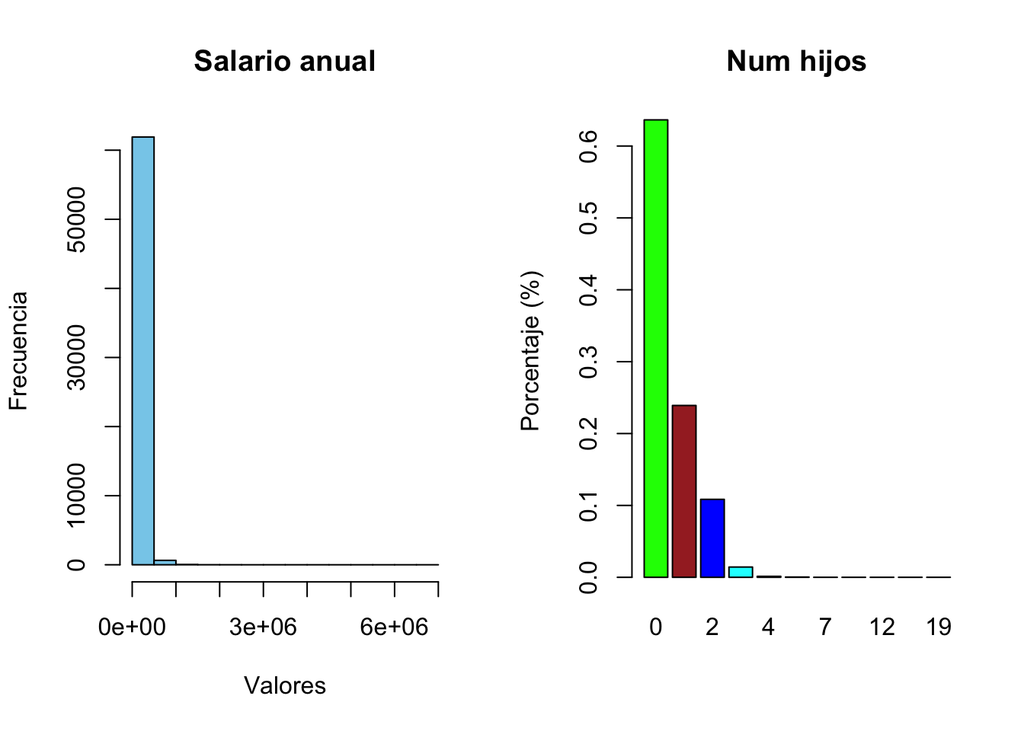

```r
par(mfrow = c(1, 2))  # Dividir la ventana de gráficos en dos

hist(df_sin_duplicados$AMT_INCOME_TOTAL,main = "Salario anual",
     xlab = "Valores",
     ylab = "Frecuencia",
     col = "skyblue",
     border = "black")

# cuentas <- table(df_sin_duplicados$AMT_INCOME_TOTAL)
# barplot(prop.table(cuentas),col=c("green","grey","blue","cyan","orange"), main=" Educación", ylab = "Porcentaje (%)" ,names.arg=c("Degree","H.education","Inc.higher","L.secondary", "Sec or sec.special"), las = 2)
cuentas <- table(df_sin_duplicados$CNT_CHILDREN)
barplot(prop.table(cuentas), col=c("green","brown","blue","cyan","orange","purple","red","yellow","black","violet","pink"),main="Num hijos", ylab = "Porcentaje (%)")
```

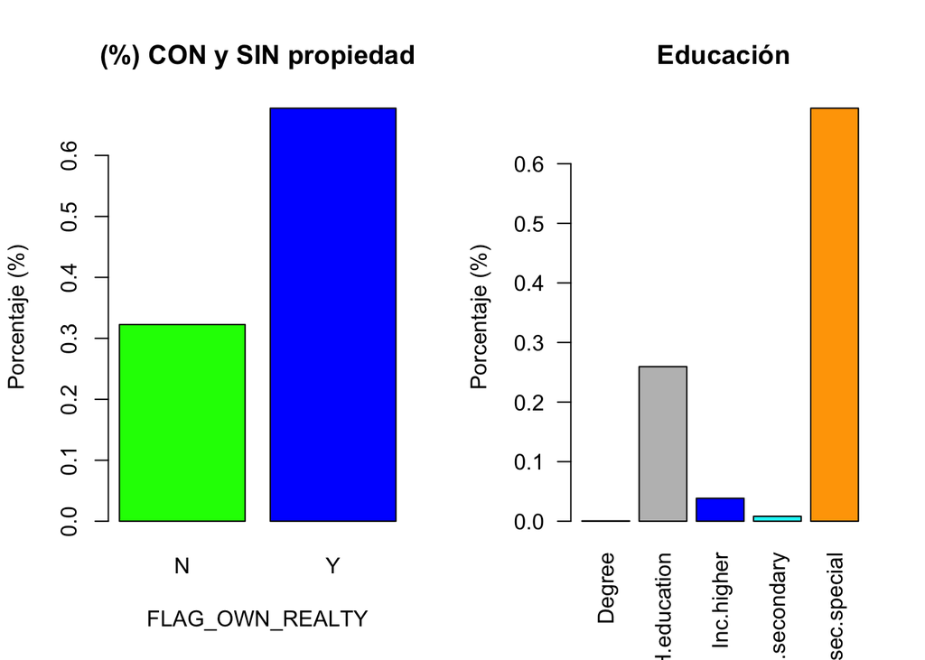

```r
cuentas <- table(df_sin_duplicados$FLAG_OWN_REALTY)
barplot(prop.table(cuentas),col=c("green","blue"), main="(%) CON y SIN propiedad",xlab ="FLAG_OWN_REALTY", ylab = "Porcentaje (%)")

cuentas <- table(df_sin_duplicados$NAME_EDUCATION_TYPE)
barplot(prop.table(cuentas),col=c("green","grey","blue","cyan","orange"), main=" Educación", ylab = "Porcentaje (%)" ,names.arg=c("Degree","H.education","Inc.higher","L.secondary", "Sec or sec.special"), las = 2)
```

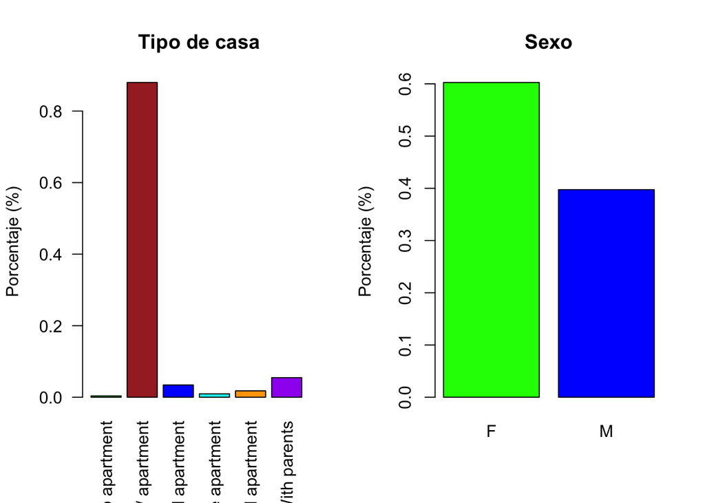

```r
cuentas <- table(df_sin_duplicados$NAME_HOUSING_TYPE)
barplot(prop.table(cuentas), col=c("green","brown","blue","cyan","orange","purple"),main=" Tipo de casa", ylab = "Porcentaje (%)", las = 2)

cuentas <- table(df_sin_duplicados$CODE_GENDER)
barplot(prop.table(cuentas), col=c("green","blue"),main="Sexo", ylab = "Porcentaje (%)")
```

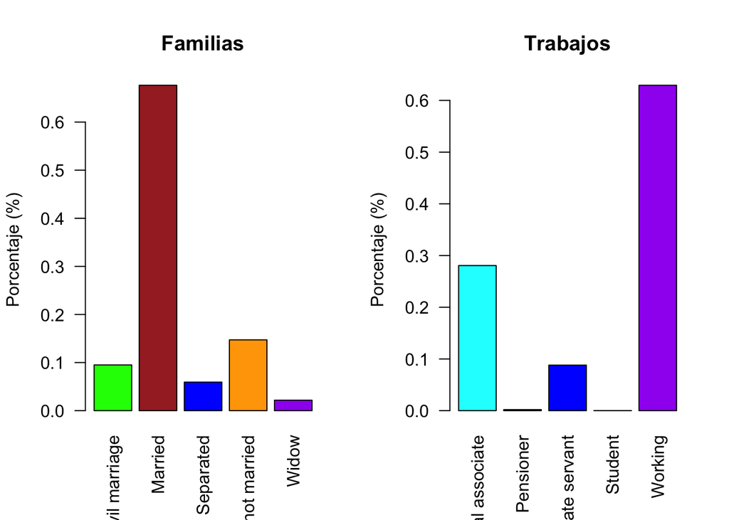

```r
cuentas <- table(df_sin_duplicados$NAME_FAMILY_STATUS)
barplot(prop.table(cuentas), col=c("green","brown","blue","orange","purple"),main="Familias", ylab = "Porcentaje (%)", las = 2)

cuentas <- table(df_sin_duplicados$NAME_INCOME_TYPE)
barplot(prop.table(cuentas), col=c("cyan","red","blue","orange","purple"),main="Trabajos", ylab = "Porcentaje (%)", las = 2)
```

Pasando al par de gráficas correspondientes a las variables de si los candidatos tienen o no propiedad y el tipo de educación de estos, se observa como para la primera, lo más común entre los candidatos es tener propiedad (~67%) mientras que un (~33%) no tiene propiedad. Respecto a la educación de los candidatos, se ve como la mayoría (~70%) solo tienen la secundaria/secundaria especial, seguido de un (~30%) de candidatos con educación superior.

En el penúltimo par de gráficas, dónde se proyecta el porcentaje para cada tipo de casas, así como el sexo de los candidatos.puede verse como la mayoría de los candidatos (~90%) viven en una casa/apartamento, seguido de un 5-7’5% de candidatos que aún viven con sus padres. Por último, y relativo al sexo de los candidatos, se observa como un 60% de los candidatos son mujeres, mientras que el 40 % son hombres. Esta variable puede resultar muy interesante, puesto que puede ayudar a entender posibles patrones o estilos de vida diferentes entre hombres y mujeres (relativos al *dataset* que se está estudiando) No obstante, con este tipo de variables hay que tener cuidado, pues hay que evitar cualquier sesgo o connotación negativa que perpetuen estereotipos acerca de un sexo o de otro en distintos ámbitos de estudio.

Se va a proceder a construir una matriz *scatterplot*, en castellano: matriz de dispersión. A fin de poder visualizar las relaciones entre variables, a partir de sus gráficos de puntos:

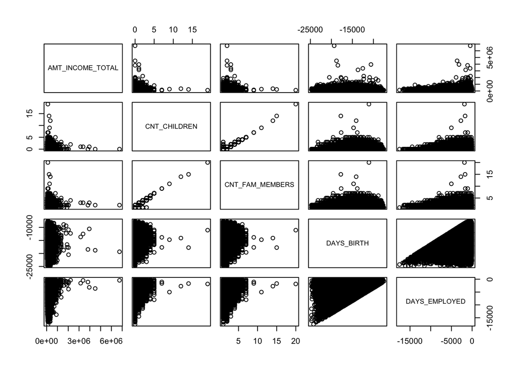

```r
pairs(df_sin_duplicados[c("AMT_INCOME_TOTAL","CNT_CHILDREN","CNT_FAM_MEMBERS","DAYS_BIRTH","DAYS_EMPLOYED")])
```

Como se puede ver por la matriz de dispersión, del ingles *scatterplot matrix* obtenida arriba, en todos los gráficos se observan algunas muestras alejadas del resto, estas muestras podrían corresponderse con *outliers* y por lo tanto hay que examinarlo (esto se hace más adelante)

Antes de analizar resultado por resultado, es pertinente recordar la dinámica de una matriz de dispersión, aquellos títulos de variables que se encuentren en la misma fila que 4 gráficas cualesquiera, determinará la coordenada y, mientras que aquellos títulos de variables que se encuentren en la misma columna que otras 4 gráficas cualesquiera, dicho título caracterizará la variable x.

Estudiando la gráfica correspondiente a la celda de la primera fila y segunda columna, se observa como la relación entre el salario anual (eje y) y la cantidad de hijos (eje x) es inversamente proporcional, ya que a medida que el número de hijos aumenta, el salario anual disminuye. Esta es una relación interesante a tener en cuenta, no obstante, cabe destacar que la correlación de estas dos variables es baja (esto puede comprobarse con la matriz de correlaciones de abajo). Este mismo comportamiento que se ha identidicado, también aplica para la cantdad de miembros del núcleo familiar, por razones obvias. Luego, para el salario anual (eje y) y el número de días del cumpleaños (eje x) se observa una especie de colina, que se parece a una distribución normal, además gráficamente puede verse como la varianza es grande, pues la colina no es muy alta. Y si bien recordamos, la varoable “AMT_INCOME_TOTAL” tenía una varianza desorbitada. Por último y cerrando esta fila, a diferencia de los dos primeros gráficos descritos, en este caso se observa una relación directamente proporcional entre el salario anual (eje y) y el número de días que el candidato lleva (empleado), no obstante, en este caso hay que tener especial cuidado, ya que la variable “DAYS_EMPLOYED” es negativa, significando esto, que si el salario anual, aumenta con el aumento de la variable “DAYS_EMPLOYED”, en la práctica, significa que el salario anual de los candidatos, aumenta según el número de días que llevan empledos disminuyen. Es decir, el salario de de los candidatos que menos llevan trabajando es mayor, lo cual suena un tanto contraproducente, y en la práctica, estas dos variables guardan una relación inversamente proporcional. De todos modos, como se puede observar, la correlación de esta fila de gráficas es baja respecto a las variables de sus respectivas columnas (se puede comprobar abajo con la matriz de correlaciones)

Pasando a la segunda fila de gráficos, se observa como la primera gráfica repite el comportamiento de la primera gráfica de la fila anterior, pero en este caso se observa como los ejes de la primera gráfica del anterior párrafo son los mismos que los de esta, pero intercambiados de eje. Luego, la segunda gráfica, correspondiente a la relación entre el número de miembros de familia (eje x) y el número de hijos (eje y) muestra un comportamiento puramente lineal y muestra una gran correlación, algo esperable, ya que esto se ha estudiado antes (más hijos implican más miembros en la familia, por lo tanto, nada nuevo). La tercera gráfica muestra un comportamiento similar al de la gráfica que tiene encima suyo. Tanto está gráfica, como la que hay encima suya (ya descrita arriba) y la que hay debajo, no se va a estudiar en profundidad porque a simple vista no muestran ningun comportamiento característico, además las variables que conforman dichas variables parecen no estar relacionadas, puesto que la variable “DAYS_BIRTH” es puramente propbabílistico. Por último, en la última gráfica de esta fila, y al igual que pasaba con la gráfica que hay encima de esta, se observa una relación inversamente proporcional entre las variables “DAYS_EMPLOYED” y la cantidad de hijos, pues cuando la cantidad de hijos aumenta, el número de días que un candidato lleva empleado disminuye.

Para simplificar el análisis y no hacerlo más largo de lo que ya es, se van a destacar los aspectos más relevantes de las tres últimas filas de graficos. En la antepenúltima fila destacamos la relación lineal obvia de la gráfica que relaciona el número de hijos con el número de familiares. De hecho, la tercera fila es bastante semejante a la segunda pues en vez de tener el número de hijos en el eje y, se tiene el número de familiares. Por lo tanto, los totalidad de los comportamientos analizados en el anterior párrafo aplican perfectamente a esta fila de gráficas, pues se sabe que las dos variables son linealmente propocionales.

En la penúltima fila, se encuentran las gráficas con los días que han pasado desde el cumpleaños del candidato, en el eje y. En las tres primeras figuras, no se obervan omportamientos característicos, no obstante, en la última figura (cumpleaños (eje y) y número de días como empleado (eje x)) se observa como la correlación entre estas dos variables es mayor respecto al resto de variables, a excepción del conjunto compuesto por el número de hijos y el número de familiares. En esta última gráfica de la penúltima fila, se observa como según disminuye el número de días en los que los candidatos han estado empleados, el número de días desde que fueron sus respectivos cumpleaños, también decrece. Esta es una relación bastante interesante, pero ahora mismo no le encuentro la lógica.

Finalizando con la última fila de figuras, no destaca ninguna figura, además, las figuras de la última fila ya se han explicado en la primera, segunda, terecer y cuarta fila. Por lo tanto no hay mucho más que añadir.

A continuación se construye la matriz corrplot, para ver en valor numérico de las correlaciones y su relación con otras variables relevantes.

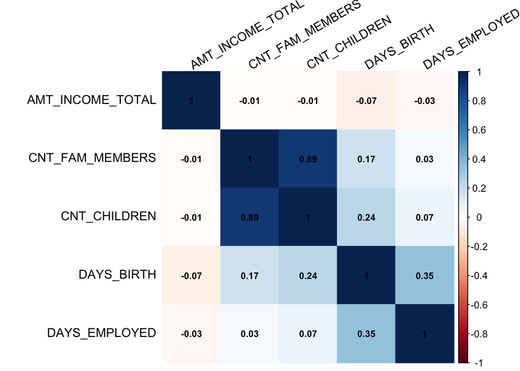

```r
if(!require("corrplot")) install.packages("corrplot"); library("corrplot")
n = c("AMT_INCOME_TOTAL","CNT_CHILDREN","CNT_FAM_MEMBERS","DAYS_BIRTH","DAYS_EMPLOYED")
factores= df_sin_duplicados %>% select(all_of(n))
res<-cor(factores)
corrplot(res,method="color",tl.col="black", tl.srt=30, order = "AOE",
number.cex=0.75,sig.level = 0.01, addCoef.col = "black")
```

Antes de estudiar la correlación más obvia del resultado obtenido arriba (matriz de correlaciones) cabe destacar la correlación significativa, que hay entre las variables “DAYS_EMPLOYED” y “DAYS_BIRTH”, viendo esta correlación: 0.35, en la escala de valores de la derecha, se ve como esta cifra, se encuentra en la parte alta, analiticamente hablando. Por lo tanto habrá que prestar atención a este conjunto de variables en estudios posteriores.

Como se puede observar, hay una gran correlación entre la variable “CNT_CHILDREN” y “CNT_FAM_MEMBERS”, pues esta es de 0.89. Esto era algo de esperar, sabiendo lo que significan los dos campos, pues “CNT_CHILDREN” refleja el número de hijos, mientras que “CNT_FAM_MEMBERS” contabiliza el número de miembros de la unidad familiar. Por lo tanto, si el número de hijos aumenta, el número de integrantes de la unidad familiar también los hace, por lo tanto, al obtener una correlación tan alta, se podría eliminar una de las variables. El criterio de eliminación de una variable es el mismo que se ha visto en teoría, y es que, el atributo que menos relación guarde con el objetivo principal del proyecto. es el que ha de ser eliminado. Por ello, se han hecho las siguientes consideraciones:

- La variable “CNT_CHILDREN” solo contabiliza los hijos, por lo que por si sola, aporta información relevante.
- La variable “CNT_FAM_MEMBERS” contempla al candidato, a sus hijos y tambien a su mujer o marido en caso de estar casado/casada.

Teniendo en cuenta los dos puntos anteriores, parece que la variable a eliminar podría ser la del número de hijos, pues la variable “CNT_FAM_MEMBERS” contempla todo el núcleo familiar y por consecuente es una variable más informativa. No obstante, también es importante conocer el número aislado de hijos, simplemente por el hecho de que los candidatos tienen la potestad de elegir si tienen o no hijos, en cambio, no tienen potestad para decidir el número exacto de integrantes familiares, ya que ducha variable viene determinada por otras dos variables (número de hijos y estado civil (NAME_FAMILY_STATUS)), por lo que en el fondo, la variable a eliminar sería: “CNT_FAM_MEMBERS”.

```r
drop <- c("CNT_FAM_MEMBERS")
df_sin_duplicados_2 = df_sin_duplicados[,!(names(df_sin_duplicados) %in% drop)]
sort(colnames(df_sin_duplicados_2)) #COMPROBAMOS QUE LO HEMOS ELIMINADO
```

```
##  [1] "AMT_INCOME_TOTAL"    "CNT_CHILDREN"        "CODE_GENDER"
##  [4] "DAYS_BIRTH"          "DAYS_EMPLOYED"       "FLAG_EMAIL"
##  [7] "FLAG_OWN_CAR"        "FLAG_OWN_REALTY"     "FLAG_PHONE"
## [10] "FLAG_WORK_PHONE"     "ID"                  "NAME_EDUCATION_TYPE"
## [13] "NAME_FAMILY_STATUS"  "NAME_HOUSING_TYPE"   "NAME_INCOME_TYPE"
## [16] "OCCUPATION_TYPE"
```

A continuación se va a proceder a eliminar los valores extremos que se han visto en la matriz de dispersión de arriba, para realizar esta tarea me he basado en el siguiente ejemplo: [Geeksforgeeks](https://www.geeksforgeeks.org/how-to-remove-outliers-from-multiple-columns-in-r-dataframe/a). Pero antes comprobamos las estadísticas del *dataframe* para luego comparar los resultados.

```r
summary(df_sin_duplicados_2)
```

```
##        ID          CODE_GENDER        FLAG_OWN_CAR       FLAG_OWN_REALTY
##  Min.   :5008806   Length:62608       Length:62608       Length:62608
##  1st Qu.:5471167   Class :character   Class :character   Class :character
##  Median :5956173   Mode  :character   Mode  :character   Mode  :character
##  Mean   :5909607
##  3rd Qu.:6288576
##  Max.   :7995770
##   CNT_CHILDREN     AMT_INCOME_TOTAL  NAME_INCOME_TYPE   NAME_EDUCATION_TYPE
##  Min.   : 0.0000   Min.   :  27000   Length:62608       Length:62608
##  1st Qu.: 0.0000   1st Qu.: 121500   Class :character   Class :character
##  Median : 0.0000   Median : 157500   Mode  :character   Mode  :character
##  Mean   : 0.5072   Mean   : 185495
##  3rd Qu.: 1.0000   3rd Qu.: 225000
##  Max.   :19.0000   Max.   :6750000
##  NAME_FAMILY_STATUS NAME_HOUSING_TYPE    DAYS_BIRTH     DAYS_EMPLOYED
##  Length:62608       Length:62608       Min.   :-24770   Min.   :-17531
##  Class :character   Class :character   1st Qu.:-17368   1st Qu.: -3250
##  Mode  :character   Mode  :character   Median :-14474   Median : -1724
##                                        Mean   :-14682   Mean   : -2428
##                                        3rd Qu.:-11784   3rd Qu.:  -817
##                                        Max.   : -7489   Max.   :   -12
##  FLAG_WORK_PHONE    FLAG_PHONE       FLAG_EMAIL     OCCUPATION_TYPE
##  Min.   :0.0000   Min.   :0.0000   Min.   :0.0000   Length:62608
##  1st Qu.:0.0000   1st Qu.:0.0000   1st Qu.:0.0000   Class :character
##  Median :0.0000   Median :0.0000   Median :0.0000   Mode  :character
##  Mean   :0.2446   Mean   :0.2697   Mean   :0.1096
##  3rd Qu.:0.0000   3rd Qu.:1.0000   3rd Qu.:0.0000
##  Max.   :1.0000   Max.   :1.0000   Max.   :1.0000
```

Lo que hace el siguiente código, es calcular el primer y tercer cuantil, para determinar si el valor de la columna que se está inspeccionando es un *outlier* o no. A partir de estas dos métricas, se calcula su diferencia como un rango intercuartílico. Entonces, si una observación es 1,5 veces el rango intercuartílico mayor que el tercer cuartil o 1,5 veces el rango intercuartílico menor que el primer cuartil, la función devuelve un *True* y dicho registro, queda categorizado como un *outlier*.

```r
# Primero se hace una copia del dataframe que hemos ido procesando a lo largo del estudio:
# df_sin_duplicados_copia<-data.frame(df_sin_duplicados_2)
#
# detector_outlier <- function(x) {
#
#     Quantile1 <- quantile(x, probs=.25) # cálculo del primer cuantil
#     Quantile3 <- quantile(x, probs=.75)  # cálculo del tercer cuantil
#     IQR = Quantile3-Quantile1 # cálculo del rango intercuartílico
#
#     # X devuelve verdadero o falso
#     x > Quantile3 + (IQR*1.5) | x < Quantile1 - (IQR*1.5)
# }
#
# # se crea la función para eliminar los outliers
# remove_outlier <- function(dataframe,
#                             columns=names(dataframe)) {
#
#     # iteramos en las columnas deseadas
#     for (col in columns) {
#         dataframe <- dataframe[!detector_outlier(dataframe[[col]]), ] # si cumple las condiciones de la función de arriba, se elimina el registro
#     }
# }
#
# remove_outlier(df_sin_duplicados_copia, c("AMT_INCOME_TOTAL","CNT_CHILDREN","CNT_FAM_MEMBERS","DAYS_BIRTH","DAYS_EMPLOYED"))
# summary(df_sin_duplicados_copia)
```

He estado teniendo muchos problemas con R-STUDIO últimamente, y misteriosamente, el código de arriba en algunas ejecuciones modifica las columnas “CNT_CHILDREN” y “AMT_INCOME_TOTAL” y en otras no, esto significa que en las ejecuciones que modifica esas dos columnas, debe de detectar *outliers*. De hecho, cuando “detecta” esos *outliers*, la columna “CNT_CHILDREN” adquiere valores negativos y decimales (no solo en la media, pero también en el valor mínimo y máximo) algo que como es obvio, no es aceptable, porque el número de hijos es siempre poitivo y entero. Pero luego, parece que la modificación que hace en la columna “AMT_INCOME_TOTAL” es más realista, ya que el salario máximo que muestra luego es de uno 61000, no obstante esto no es aceptable, pues la mayría de los candidatos tienen salarios mucho más elevados. Además se ha visto como se modifican otras variables, de manera significativa, por lo que finalmente se ha optado por comentar este código, ya que no estaba seguro de los resultados.

Es por lo anterior, que se concluye el estudio de los *outliers* estableciendo que no hay *outliers* en el juego de datos, pero si que ha valores elevados, que aunque parezcan muy grandes (como el valor máximo de 6750000 en la columna “AMT_INCOME_TOTAL”), se corresponden con datos reales, de hecho es lo que se menciona en la página web del *dataset* que puede encontrarse en el apartado de las referencias de este documento.

```r
# if (!require('tidyverse')) install.packages('tidyverse'); library('tidyverse')
# cor.test(x = df_sin_duplicados$AMT_INCOME_TOTAL, y = df_sin_duplicados$DAYS_EMPLOYED, method = "kendall")
# ggplot(data = df_sin_duplicados, aes(x = PERSONS, y = log(FATALS))) + geom_point(color = "gray30") + geom_smooth(color = "firebrick") + theme_bw() +ggtitle("Correlación entre personas implicadas en el accidente y número de muertes")
```

Ahora se comprueba de nuevo las estadísticas de las variables del *dataframe* para comprobar si se han eliminado los valores extremos de 19 hijos en la columna “CNT_CHILDREN” y la cantidad 6750000 en la columna “AMT_INCOME_TOTAL”

```r
# summary(df_sin_duplicados_copia)
```

```r
summary(df_sin_duplicados_2)
```

```
##        ID          CODE_GENDER        FLAG_OWN_CAR       FLAG_OWN_REALTY
##  Min.   :5008806   Length:62608       Length:62608       Length:62608
##  1st Qu.:5471167   Class :character   Class :character   Class :character
##  Median :5956173   Mode  :character   Mode  :character   Mode  :character
##  Mean   :5909607
##  3rd Qu.:6288576
##  Max.   :7995770
##   CNT_CHILDREN     AMT_INCOME_TOTAL  NAME_INCOME_TYPE   NAME_EDUCATION_TYPE
##  Min.   : 0.0000   Min.   :  27000   Length:62608       Length:62608
##  1st Qu.: 0.0000   1st Qu.: 121500   Class :character   Class :character
##  Median : 0.0000   Median : 157500   Mode  :character   Mode  :character
##  Mean   : 0.5072   Mean   : 185495
##  3rd Qu.: 1.0000   3rd Qu.: 225000
##  Max.   :19.0000   Max.   :6750000
##  NAME_FAMILY_STATUS NAME_HOUSING_TYPE    DAYS_BIRTH     DAYS_EMPLOYED
##  Length:62608       Length:62608       Min.   :-24770   Min.   :-17531
##  Class :character   Class :character   1st Qu.:-17368   1st Qu.: -3250
##  Mode  :character   Mode  :character   Median :-14474   Median : -1724
##                                        Mean   :-14682   Mean   : -2428
##                                        3rd Qu.:-11784   3rd Qu.:  -817
##                                        Max.   : -7489   Max.   :   -12
##  FLAG_WORK_PHONE    FLAG_PHONE       FLAG_EMAIL     OCCUPATION_TYPE
##  Min.   :0.0000   Min.   :0.0000   Min.   :0.0000   Length:62608
##  1st Qu.:0.0000   1st Qu.:0.0000   1st Qu.:0.0000   Class :character
##  Median :0.0000   Median :0.0000   Median :0.0000   Mode  :character
##  Mean   :0.2446   Mean   :0.2697   Mean   :0.1096
##  3rd Qu.:0.0000   3rd Qu.:1.0000   3rd Qu.:0.0000
##  Max.   :1.0000   Max.   :1.0000   Max.   :1.0000
```

También es importante llevar a cabo una normalización de las variables, pues tal y como se pudo ver en la PEC anterior, este procedimiento permitió la correcta aplicación de algoritmos como los *k-means*, donde claramente se vió como si no se normalizaban los datos, los resultados que arrojaba el algoritmo no eran buenos. Esto se debe a la diferencia de escala entre variables, siendo esto el principal detonante, en cuanto a contribuciones desequilibradas de distinas variables en el modelo.

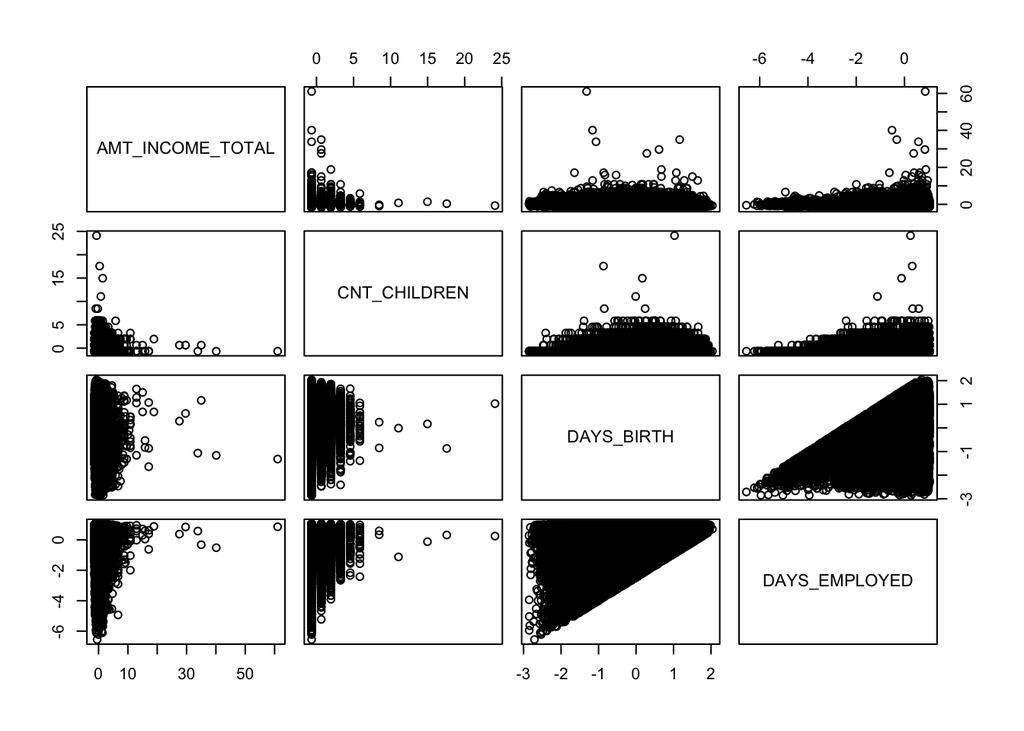

```r
# Se especifican las columnas que se quieren normalizar
norm_cols <- c("AMT_INCOME_TOTAL","CNT_CHILDREN","DAYS_BIRTH","DAYS_EMPLOYED")

# Se normalizan las columnas deseadas
df_sin_duplicados[norm_cols] <- scale(df_sin_duplicados_2[norm_cols])

pairs(df_sin_duplicados[c("AMT_INCOME_TOTAL","CNT_CHILDREN","DAYS_BIRTH","DAYS_EMPLOYED")])
```

```r
summary(df_sin_duplicados_2)
```

```
##        ID          CODE_GENDER        FLAG_OWN_CAR       FLAG_OWN_REALTY
##  Min.   :5008806   Length:62608       Length:62608       Length:62608
##  1st Qu.:5471167   Class :character   Class :character   Class :character
##  Median :5956173   Mode  :character   Mode  :character   Mode  :character
##  Mean   :5909607
##  3rd Qu.:6288576
##  Max.   :7995770
##   CNT_CHILDREN     AMT_INCOME_TOTAL  NAME_INCOME_TYPE   NAME_EDUCATION_TYPE
##  Min.   : 0.0000   Min.   :  27000   Length:62608       Length:62608
##  1st Qu.: 0.0000   1st Qu.: 121500   Class :character   Class :character
##  Median : 0.0000   Median : 157500   Mode  :character   Mode  :character
##  Mean   : 0.5072   Mean   : 185495
##  3rd Qu.: 1.0000   3rd Qu.: 225000
##  Max.   :19.0000   Max.   :6750000
##  NAME_FAMILY_STATUS NAME_HOUSING_TYPE    DAYS_BIRTH     DAYS_EMPLOYED
##  Length:62608       Length:62608       Min.   :-24770   Min.   :-17531
##  Class :character   Class :character   1st Qu.:-17368   1st Qu.: -3250
##  Mode  :character   Mode  :character   Median :-14474   Median : -1724
##                                        Mean   :-14682   Mean   : -2428
##                                        3rd Qu.:-11784   3rd Qu.:  -817
##                                        Max.   : -7489   Max.   :   -12
##  FLAG_WORK_PHONE    FLAG_PHONE       FLAG_EMAIL     OCCUPATION_TYPE
##  Min.   :0.0000   Min.   :0.0000   Min.   :0.0000   Length:62608
##  1st Qu.:0.0000   1st Qu.:0.0000   1st Qu.:0.0000   Class :character
##  Median :0.0000   Median :0.0000   Median :0.0000   Mode  :character
##  Mean   :0.2446   Mean   :0.2697   Mean   :0.1096
##  3rd Qu.:0.0000   3rd Qu.:1.0000   3rd Qu.:0.0000
##  Max.   :1.0000   Max.   :1.0000   Max.   :1.0000
```

```r
summary(df_sin_duplicados_2)
```

```
##        ID          CODE_GENDER        FLAG_OWN_CAR       FLAG_OWN_REALTY
##  Min.   :5008806   Length:62608       Length:62608       Length:62608
##  1st Qu.:5471167   Class :character   Class :character   Class :character
##  Median :5956173   Mode  :character   Mode  :character   Mode  :character
##  Mean   :5909607
##  3rd Qu.:6288576
##  Max.   :7995770
##   CNT_CHILDREN     AMT_INCOME_TOTAL  NAME_INCOME_TYPE   NAME_EDUCATION_TYPE
##  Min.   : 0.0000   Min.   :  27000   Length:62608       Length:62608
##  1st Qu.: 0.0000   1st Qu.: 121500   Class :character   Class :character
##  Median : 0.0000   Median : 157500   Mode  :character   Mode  :character
##  Mean   : 0.5072   Mean   : 185495
##  3rd Qu.: 1.0000   3rd Qu.: 225000
##  Max.   :19.0000   Max.   :6750000
##  NAME_FAMILY_STATUS NAME_HOUSING_TYPE    DAYS_BIRTH     DAYS_EMPLOYED
##  Length:62608       Length:62608       Min.   :-24770   Min.   :-17531
##  Class :character   Class :character   1st Qu.:-17368   1st Qu.: -3250
##  Mode  :character   Mode  :character   Median :-14474   Median : -1724
##                                        Mean   :-14682   Mean   : -2428
##                                        3rd Qu.:-11784   3rd Qu.:  -817
##                                        Max.   : -7489   Max.   :   -12
##  FLAG_WORK_PHONE    FLAG_PHONE       FLAG_EMAIL     OCCUPATION_TYPE
##  Min.   :0.0000   Min.   :0.0000   Min.   :0.0000   Length:62608
##  1st Qu.:0.0000   1st Qu.:0.0000   1st Qu.:0.0000   Class :character
##  Median :0.0000   Median :0.0000   Median :0.0000   Mode  :character
##  Mean   :0.2446   Mean   :0.2697   Mean   :0.1096
##  3rd Qu.:0.0000   3rd Qu.:1.0000   3rd Qu.:0.0000
##  Max.   :1.0000   Max.   :1.0000   Max.   :1.0000
```

Nótese como ahora hay una variable menos, porque como bien se ha comentado antes, anteriomente se ha optado por eliminar la variable “CNT_FAM_MEMBERS” puesto que no aportaba información adicional al juego de datos.

Como puede verse en la matriz de dispersión de arriba, los datos son más uniformes, y siguen tendencias más claras. La normalización será de especial importancia de cara a la implementación del modelo deseado, pues determinará la calidad de los resultados y la adaptación del modelo a los datos.

Se ha sacado bastante información del juego de datos, así como relaciones muy valiosas, gracias principalmente a las *scatterplot matrices*. Además se ha hecho una liempieza exhaustiva de los datos, que al principio ha supuesto un gran reto, por la cantidad de datos duplicados que había, valores vacíos, etc. Hay muchos pasos estudiados en el primer tema de la asigntura, que no se han tenido que implementar en este estudio, simplementa porque no aplicaban al juego de datos escogido, un ejemplo es: la aproximación decimal.

En el siguiente apartado se va a proceder con la discretización de varias variables numéricas.

## 3.4 Discretización

El método de discretización de variables, es un método muy común dentro del mundo del aprendizaje automático (*machine learning*) ya que, como bien hemos estudiado en teoría, su implemetación en un juego de datos trae múltiples ventajas, como por ejemplo: reducción del coste computacinal, incremento del proceso de aprendizaje, disminución de espacio de almacenaje, disminución de tamaño del modelo resultante. Además de que la implemetación de este tipo de técnicas, mejora la comprensión de algunos modelos, porque hay menos términos descriptivos. Tal y como ya vimos en el primer tema de teoría y como dijo Pablo Picasso: “El arte está en eliminar lo innecesario”. Esto proceso también tiene relación con un paso que ya se ha dado en el anterior apartado, que es el de eliminar variables que no aportan información, por lo que, podríamos decir que el *dataset* va por buen camino.

Adicionalmente, Irán Apolinar en [RPubs](https://rpubs.com/IranNash/discretizacion), explica como la gran cantidad de variables continuas en un juego de datos, pueden complicar el aprendizaje del modelo aplicado. Por lo tanto, al convertir una variable continua, en una discreta, estaremos permitiendo que el algoritmo trabaje con la frecuencia en términos de ocurrencia, del nuevo conjunto finito de valores, construido a partir de un conjunto enorme de valores.

Las variables candidatas que se han identificado son las siguientes:

- **“AMT_INCOME_TOTAL”**. Es una de las variables numéricas, con más diferencia entre diferentes registros, pues su varianza es de 11567351907.
- **“DAYS_EMPLOYED”**. Es una variable con mucha varianza, ya que esta es de 5313812. Por lo tanto, discretizar este valor para poder identificar los rangos numéricos más frecuentados, es una obligación para facilitarle en un futuro, la tarea de aprendizaje al modelo predictivo (i.e., modelo de clasificación)
- **“DAYS_BIRTH”**. Este es una variable que contempla una gran cantidad de valores, por ello su varianza es tan alta: 12482904. Por lo tanto, la identificación de regiones/intervalos de partición, contribuiría positivamente en el aprendizaje del modelo.

```r
cat("Varianza variable AMT_INCOME_TOTAL: ", var(df_sin_duplicados_2["AMT_INCOME_TOTAL"]),"\n")
```

```
## Varianza variable AMT_INCOME_TOTAL:  11567351907
```

```r
cat("Varianza variable DAYS_EMPLOYED: ", var(df_sin_duplicados_2["DAYS_EMPLOYED"]),"\n")
```

```
## Varianza variable DAYS_EMPLOYED:  5313812
```

```r
cat("Varianza variable DAYS_BIRTH: ", var(df_sin_duplicados_2["DAYS_BIRTH"]),"\n")
```

```
## Varianza variable DAYS_BIRTH:  12482904
```

Primero hay que elegir el tipo de discretización que se quiere llevar a cabo, como se vió en teotía, hay varias formas:

- Método de partición en intervalos de la misma amplitud.
- Obtención de intervalos de discretización de igual frecuencia.
- Método de partición basado en el algoritmo *k-means*.

Como se ha mencionado antes, lo que se quiere es que el modelo pueda tener en cuenta la frecuencia con la que un intervalo aparece en un juego de datos por lo tanto. Tanto el primer método como el segundo quedan descartados. Además, como se vió en tería, el primer método no es capaz de encontrar un valor de *k* suficientemente bueno.

Dicho esto, nos podríamos decantar por el último método: **Método de partición basado en el algoritmo *k-means*.**, la base de este método la vimos en profundidad, en la teoría y en la PEC del segundo tema, y se sabe que aunque tiene muchos aspectos que mejorar, si se le meten unos buenos datos normalizados, este método basado en el algoritmo de *k-means* podría arrojar buenos resultados. No obstante, primero se van a discretizar las variables sin los datos normalizados.

```r
# Utilizaremos la función discretize de arules: This function implements several basic unsupervised methods to convert a continuous variable into a categorical variable (factor) using different binning strategies.
# https://cran.r-project.org/web/packages/arules/index.html
if (!require('arules')) install.packages('arules'); library('arules')
set.seed(2)

# Primero se comienza por la variable: "AMT_INCOME_TOTAL"
table(discretize(df_sin_duplicados_2$AMT_INCOME_TOTAL, "cluster" ))
```

```
##
##   [2.7e+04,1.7e+05)  [1.7e+05,3.13e+05) [3.13e+05,6.75e+06]
##               32696               23951                5961
```

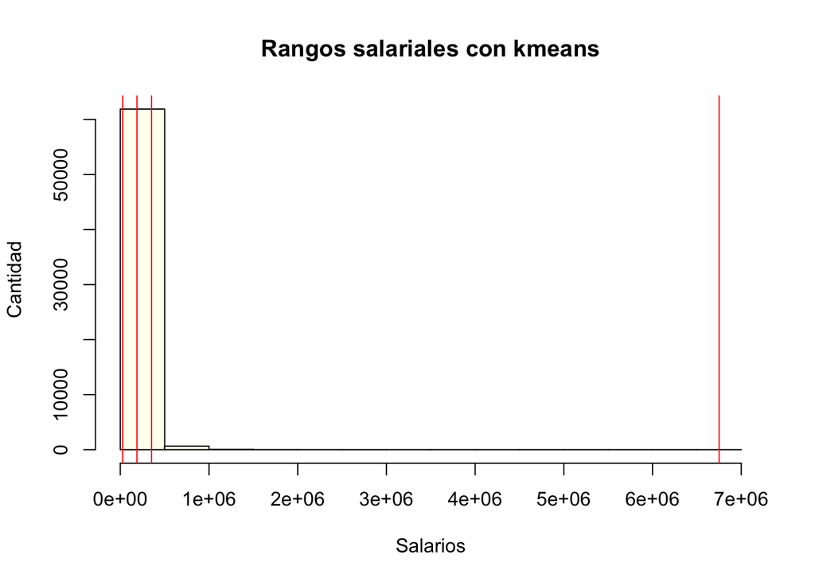

```r
hist(df_sin_duplicados_2$AMT_INCOME_TOTAL, main="Rangos salariales con kmeans",xlab="Salarios", ylab="Cantidad",col = "ivory")
abline(v=discretize(df_sin_duplicados_2$AMT_INCOME_TOTAL, method="cluster", onlycuts=TRUE),col="red")
```

```r
# Segundo se sigue con la variable: "DAYS_EMPLOYED"
table(discretize(df_sin_duplicados_2$DAYS_EMPLOYED, "cluster" ))
```

```
##
## [-1.75e+04,-6.21e+03) [-6.21e+03,-2.42e+03)       [-2.42e+03,-12]
##                  4489                 18767                 39352
```

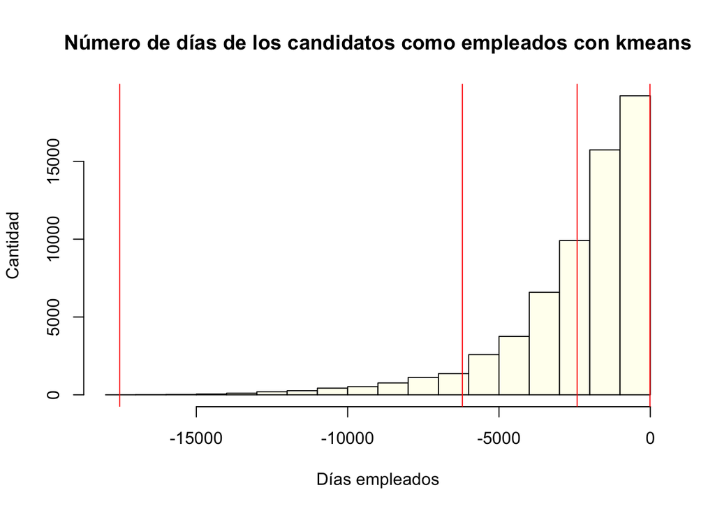

```r
hist(df_sin_duplicados_2$DAYS_EMPLOYED, main="Número de días de los candidatos como empleados con kmeans",xlab="Días empleados", ylab="Cantidad",col = "ivory")
abline(v=discretize(df_sin_duplicados_2$DAYS_EMPLOYED, method="cluster", onlycuts=TRUE),col="red")
```

```r
# Tercero se sigue con la  la variable: "DAYS_BIRTH"
table(discretize(df_sin_duplicados_2$DAYS_BIRTH, "cluster" ))
```

```
##
## [-2.48e+04,-1.71e+04) [-1.71e+04,-1.29e+04) [-1.29e+04,-7.49e+03]
##                 16885                 23712                 22011
```

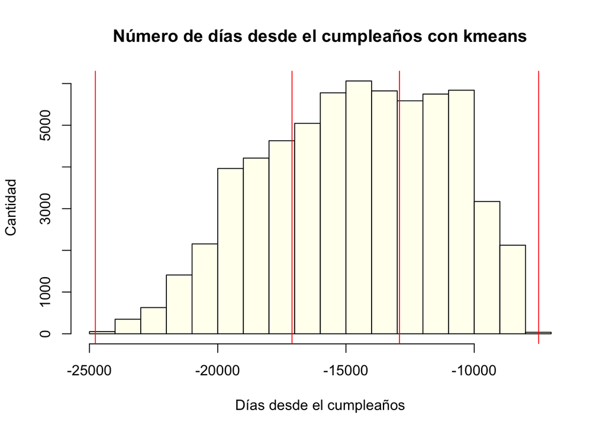

```r
hist(df_sin_duplicados_2$DAYS_BIRTH, main="Número de días desde el cumpleaños con kmeans",xlab="Días desde el cumpleaños", ylab="Cantidad",col = "ivory")
abline(v=discretize(df_sin_duplicados_2$DAYS_BIRTH, method="cluster", onlycuts=TRUE),col="red")
```

Se puede notar, como al ejecutar el algoritmo sin especificar ningún argumento y permitiendo que el sistema seleccione el conjunto de particiones, se pueden visualizar tres grupos que categorizan a las tres variables. Esto va a servir de gran ayuda al modelo de clasificación en la próxima práctica.

Ahora, con estos resultados, se puede asignar cada uno de los grupos como una nueva variable en el conjunto de datos para el estudio previo que habrá que realizar, al momento de meter el juego de datos en el modelo.

```r
df_sin_duplicados_2$AMT_INCOME_TOTAL_DIS <- (discretize(df_sin_duplicados_2$AMT_INCOME_TOTAL, "cluster" ))
head(df_sin_duplicados_2$AMT_INCOME_TOTAL_DIS)
```

```
## [1] [2.7e+04,2.7e+05) [2.7e+04,2.7e+05) [2.7e+04,2.7e+05) [2.7e+04,2.7e+05)
## [5] [2.7e+04,2.7e+05) [2.7e+04,2.7e+05)
## Levels: [2.7e+04,2.7e+05) [2.7e+05,1.66e+06) [1.66e+06,6.75e+06]
```

```r
df_sin_duplicados_2$DAYS_EMPLOYED_DIS <- (discretize(df_sin_duplicados_2$DAYS_EMPLOYED, "cluster" ))
head(df_sin_duplicados_2$DAYS_EMPLOYED_DIS)
```

```
## [1] [-2.42e+03,-12]       [-6.21e+03,-2.42e+03) [-2.42e+03,-12]
## [4] [-2.42e+03,-12]       [-2.42e+03,-12]       [-2.42e+03,-12]
## Levels: [-1.75e+04,-6.21e+03) [-6.21e+03,-2.42e+03) [-2.42e+03,-12]
```

```r
df_sin_duplicados_2$DAYS_BIRTH_DIS <- (discretize(df_sin_duplicados_2$DAYS_BIRTH, "cluster" ))
head(df_sin_duplicados_2$DAYS_BIRTH_DIS)
```

```
## [1] [-2.48e+04,-1.71e+04) [-2.48e+04,-1.71e+04) [-1.71e+04,-1.29e+04)
## [4] [-2.48e+04,-1.71e+04) [-1.29e+04,-7.49e+03] [-1.29e+04,-7.49e+03]
## 3 Levels: [-2.48e+04,-1.71e+04) ... [-1.29e+04,-7.49e+03]
```

Ahora se comprueba la inclusión de estas tres nuevas variables, en el juego de datos:

```r
summary(df_sin_duplicados_2)
```

```
##        ID          CODE_GENDER        FLAG_OWN_CAR       FLAG_OWN_REALTY
##  Min.   :5008806   Length:62608       Length:62608       Length:62608
##  1st Qu.:5471167   Class :character   Class :character   Class :character
##  Median :5956173   Mode  :character   Mode  :character   Mode  :character
##  Mean   :5909607
##  3rd Qu.:6288576
##  Max.   :7995770
##   CNT_CHILDREN     AMT_INCOME_TOTAL  NAME_INCOME_TYPE   NAME_EDUCATION_TYPE
##  Min.   : 0.0000   Min.   :  27000   Length:62608       Length:62608
##  1st Qu.: 0.0000   1st Qu.: 121500   Class :character   Class :character
##  Median : 0.0000   Median : 157500   Mode  :character   Mode  :character
##  Mean   : 0.5072   Mean   : 185495
##  3rd Qu.: 1.0000   3rd Qu.: 225000
##  Max.   :19.0000   Max.   :6750000
##  NAME_FAMILY_STATUS NAME_HOUSING_TYPE    DAYS_BIRTH     DAYS_EMPLOYED
##  Length:62608       Length:62608       Min.   :-24770   Min.   :-17531
##  Class :character   Class :character   1st Qu.:-17368   1st Qu.: -3250
##  Mode  :character   Mode  :character   Median :-14474   Median : -1724
##                                        Mean   :-14682   Mean   : -2428
##                                        3rd Qu.:-11784   3rd Qu.:  -817
##                                        Max.   : -7489   Max.   :   -12
##  FLAG_WORK_PHONE    FLAG_PHONE       FLAG_EMAIL     OCCUPATION_TYPE
##  Min.   :0.0000   Min.   :0.0000   Min.   :0.0000   Length:62608
##  1st Qu.:0.0000   1st Qu.:0.0000   1st Qu.:0.0000   Class :character
##  Median :0.0000   Median :0.0000   Median :0.0000   Mode  :character
##  Mean   :0.2446   Mean   :0.2697   Mean   :0.1096
##  3rd Qu.:0.0000   3rd Qu.:1.0000   3rd Qu.:0.0000
##  Max.   :1.0000   Max.   :1.0000   Max.   :1.0000
##           AMT_INCOME_TOTAL_DIS             DAYS_EMPLOYED_DIS
##  [2.7e+04,2.7e+05)  :55307     [-1.75e+04,-6.21e+03): 4489
##  [2.7e+05,1.66e+06) : 7287     [-6.21e+03,-2.42e+03):18767
##  [1.66e+06,6.75e+06]:   14     [-2.42e+03,-12]      :39352
##
##
##
##                DAYS_BIRTH_DIS
##  [-2.48e+04,-1.71e+04):16885
##  [-1.71e+04,-1.29e+04):23712
##  [-1.29e+04,-7.49e+03]:22011
##
##
##
```

```r
head(df_sin_duplicados_2)
```

```
##         ID CODE_GENDER FLAG_OWN_CAR FLAG_OWN_REALTY CNT_CHILDREN
## 3  5008806           M            Y               Y            0
## 4  5008808           F            N               Y            0
## 11 5008815           M            Y               Y            0
## 14 5008819           M            Y               Y            0
## 20 5008825           F            Y               N            0
## 22 5008830           F            N               Y            0
##    AMT_INCOME_TOTAL     NAME_INCOME_TYPE           NAME_EDUCATION_TYPE
## 3            112500              Working Secondary / secondary special
## 4            270000 Commercial associate Secondary / secondary special
## 11           270000              Working              Higher education
## 14           135000 Commercial associate Secondary / secondary special
## 20           130500              Working             Incomplete higher
## 22           157500              Working Secondary / secondary special
##      NAME_FAMILY_STATUS NAME_HOUSING_TYPE DAYS_BIRTH DAYS_EMPLOYED
```

[output cut: 20 more lines]

A continuación se discretizan las variables normalizadas anteriormente.

```r
# Utilizaremos la función discretize de arules: This function implements several basic unsupervised methods to convert a continuous variable into a categorical variable (factor) using different binning strategies.
# https://cran.r-project.org/web/packages/arules/index.html
if (!require('arules')) install.packages('arules'); library('arules')
set.seed(2)

# Primero se comienza por la variable: "AMT_INCOME_TOTAL"
table(discretize(df_sin_duplicados$AMT_INCOME_TOTAL, "cluster" ))
```

```
##
## [-1.47,-0.147)  [-0.147,1.18)      [1.18,61]
##          32696          23951           5961
```

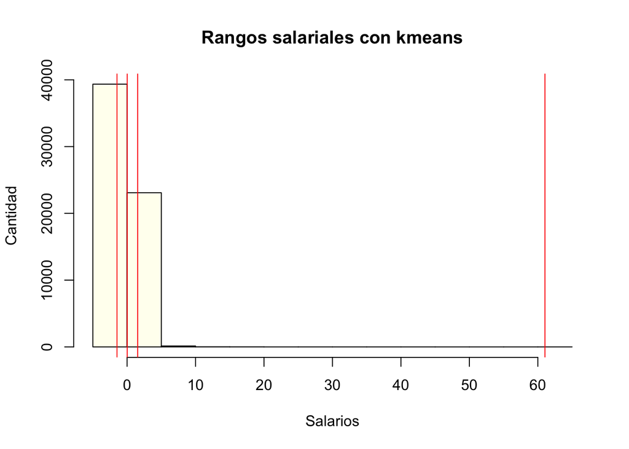

```r
hist(df_sin_duplicados$AMT_INCOME_TOTAL, main="Rangos salariales con kmeans",xlab="Salarios", ylab="Cantidad",col = "ivory")
abline(v=discretize(df_sin_duplicados$AMT_INCOME_TOTAL, method="cluster", onlycuts=TRUE),col="red")
```

```r
# Segundo se sigue con la variable: "DAYS_EMPLOYED"
table(discretize(df_sin_duplicados$DAYS_EMPLOYED, "cluster" ))
```

```
##
##   [-6.55,-1.64) [-1.64,0.00387)  [0.00387,1.05]
##            4489           18767           39352
```

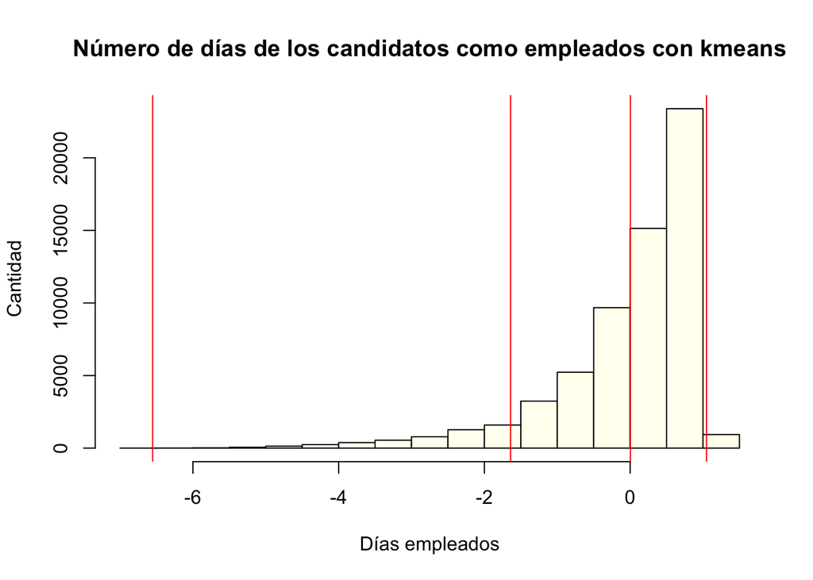

```r
hist(df_sin_duplicados$DAYS_EMPLOYED, main="Número de días de los candidatos como empleados con kmeans",xlab="Días empleados", ylab="Cantidad",col = "ivory")
abline(v=discretize(df_sin_duplicados$DAYS_EMPLOYED, method="cluster", onlycuts=TRUE),col="red")
```

```r
# Tercero se sigue con la  la variable: "DAYS_BIRTH"
table(discretize(df_sin_duplicados$DAYS_BIRTH, "cluster" ))
```

```
##
## [-2.86,-0.685)   [-0.685,0.5)     [0.5,2.04]
##          16885          23712          22011
```

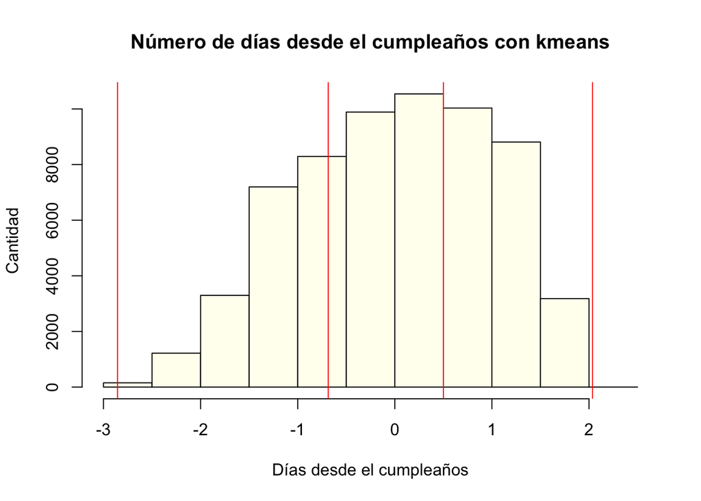

```r
hist(df_sin_duplicados$DAYS_BIRTH, main="Número de días desde el cumpleaños con kmeans",xlab="Días desde el cumpleaños", ylab="Cantidad",col = "ivory")
abline(v=discretize(df_sin_duplicados$DAYS_BIRTH, method="cluster", onlycuts=TRUE),col="red")
```

Como se puede observar, y comparando los resultados de arriba con los grupos obtenidos para el conjunto de datos sin normalizar, los grupos que se han obtenido en esta última discretización son exactamente los mismos que los que se han obtenido antes. Con la única diferencia de que los datos, al estar normalizados, varían ligeramente. En este caso, no se está aplicando el algoritmo de *k-means* como tal, sino un método de discretización basado en el *k-means* (algoritmo no supervisado) y por eso no vemos gran cambio entre la discretización de datos normalizados y sin normalizar.

## 3.5 Aplicación de estudios PCA y SVD

Tanto el PCA: “análisis de componentes principales”, del inglés: *“Principal Component Analysis”*, como la SVD: “descomposición de valores singulares”, del inglés: *“Singular Value Decomposition”*, son metodologías que permiten trabajar con nuevas características llamadas componentes, que resultan ser independientes entre sí. En esencia, ambas técnicas hacen posible la representación del conjunto de datos en un nuevo sistema de coordenadas que se denomina componentes principales. Este sistema se ajusta óptimamente, a la distribución del juego de datos, capturando de manera más eficiente su variabilidad.

A continuación se lleva a cabo el análisis de componentes principales en el juego de datos mediante la implementación del siguiente *chunk* de código. No obstante, primero, para asegurarnos de que se lleva a cabo correctamente el proceso, se van a normalizar, las columnas de valores enteros. Esta normalización se lleva a cabo para estandarizar las escalas de las variables continuas, por ello no se van a normalizar variables binarias, ya que solo toman dos valores (1 o 0), y por lo tanto ya están en una escala determinada. Dicho esto, véase la normalización y el análisis de componentes principales a continuación:

```r
# Se normalizan las columnas
nor <-function(x) { (x -min(x))/(max(x)-min(x))}

# Guardamos un nuevo dataset normalizado
df_sin_duplicados_2$type<- NULL
n = c("CNT_CHILDREN","AMT_INCOME_TOTAL","DAYS_BIRTH","DAYS_EMPLOYED")
df_sin_duplicados_2<- df_sin_duplicados_2 %>% select(all_of(n))
df_sin_duplicados_2_nor <- as.data.frame(lapply(df_sin_duplicados_2, nor))

# Se visualiza solo el principio
head(df_sin_duplicados_2_nor)
```

```
##   CNT_CHILDREN AMT_INCOME_TOTAL DAYS_BIRTH DAYS_EMPLOYED
## 1            0       0.01271754  0.1907297     0.9359552
## 2            0       0.03614458  0.3275273     0.8265312
## 3            0       0.03614458  0.4570337     0.9567898
## 4            0       0.01606426  0.4046062     0.9325304
## 5            0       0.01539491  0.8159829     0.9377248
## 6            0       0.01941098  0.8529020     0.9168332
```

```r
pca.acc <- prcomp(df_sin_duplicados_2_nor)
summary(pca.acc)
```

```
## Importance of components:
##                           PC1    PC2     PC3     PC4
## Standard deviation     0.2122 0.1191 0.03919 0.01596
## Proportion of Variance 0.7383 0.2324 0.02517 0.00418
## Cumulative Proportion  0.7383 0.9707 0.99582 1.00000
```

Como se puede ver por el resultado de arriba, ya se han normalizado correctamente las 4 variables continuas del juego de datos.

Ahora bien, analizando los resultados devueltos por la función summary, se observa como esta ha devuelto, la desviación estándar, la proporción cumulativa, y la proporción de varianza aplicada al conjunto total de cada variable. Esto explica, que la variable PC1 tenga una proporción de varianza de 0.7383 (una variabilidad del todo el conjunto de datos de 0.7383), mientras que la variable PC4 solamente tiene una proporción de 0.00418 de variabilidad del total de datos.

Ahora se va a representar el histograma asociado, a fin de visualizar el protagononismo que tiene cada variable en el conjunto total de datos:

```r
if (!require('factoextra')) install.packages('factoextra'); library('factoextra')
# Los valores propios se corresponden con la cantidad de variación asociada a cada componente principal (PC).
ev= get_eig(pca.acc)
ev
```

```
##         eigenvalue variance.percent cumulative.variance.percent
## Dim.1 0.0450371932       73.8297606                    73.82976
## Dim.2 0.0141738212       23.2352362                    97.06500
## Dim.3 0.0015355926        2.5173069                    99.58230
## Dim.4 0.0002548007        0.4176964                   100.00000
```

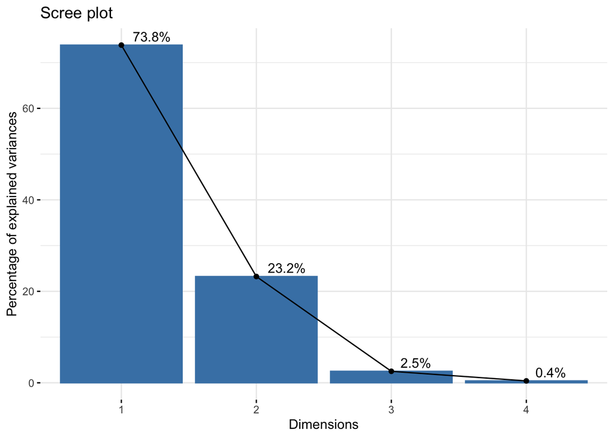

```r
fviz_eig(pca.acc, addlabels=TRUE, hjust = -0.3)
```

Arriba, pueden verse gráficamente, los datos ya estudiados de manera analítica, en el *chunk* anterior. Por lo tanto no hay información adicional.

No obstante, cabe destacar, que, con el objetivo de decidir, cuales de las variables que se han obtenido, van a ser escogidas, se ha aplicado el criterio de Káiser. Este criterio, estipula que todas las variables con varianza superior a 1 se mantienen, y es el mismo, el que tomará la decisión sobre las variables obtenidas.

Seguidamente, se calcula varianza de los 4 “PCs” a partir de la desviación estándar

```r
var_acc <- pca.acc$sdev^2
var_acc
```

```
## [1] 0.0450371932 0.0141738212 0.0015355926 0.0002548007
```

Con los resultados obtenidos es muy complicado decidir cuáles son los componentes principales componentes a escoger. *Este hecho podría estar causado por no haber escalado los datos previamente.* Por lo tanto, el siguiente paso es escalar los datos y volver a calcular la varianza para ver qué datos selecciona.

Resulta difícil determinar que componentes son las principales, a partir de las varianzas obtenidas arriba, ya que según el criterio de Káiser, las varianzas superiores a 1 se mantienen, no obstante, ninguna de las varianzas es capaz de llegar a la unidad. Esto puede deberse a que los datos no han sido previamente escalados, y es exactamente esto último lo que se va hacer a continuación, para poder calcular de nuevo las varianzas, y así distinguir mejor cuales componentes principales escoger.

```r
# Escalamos los datos
acc_scale <- scale(df_sin_duplicados_2_nor)
# Calculamos las componentes principales
pca.acc_scale <- prcomp(acc_scale)
# Mostramos la varianza de dichas variables:
var_acc_scale <- pca.acc_scale$sdev^2
head(var_acc_scale)
```

```
## [1] 1.4627710 0.9925818 0.9374712 0.6071760
```

Efectivamente, se trataba de un tema de escalado de datos, como bien se puede ver por el resultado de arriba, solo hay una componente principal que supera la unidad, y por lo tanto es la única componente principal de entre las 4 variables inciales propuestas.

Ahora se muestra el histograma de porcentaje de varianza explicado, con los datos escalados:

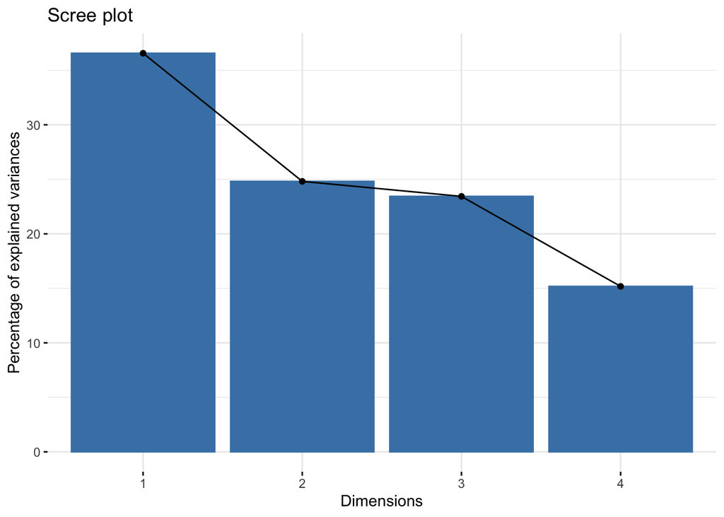

```r
fviz_eig(pca.acc_scale)
```

```r
ev = get_eig(pca.acc_scale)
ev
```

```
##       eigenvalue variance.percent cumulative.variance.percent
## Dim.1  1.4627710         36.56927                    36.56927
## Dim.2  0.9925818         24.81454                    61.38382
## Dim.3  0.9374712         23.43678                    84.82060
## Dim.4  0.6071760         15.17940                   100.00000
```

Según (Káiser en 1961), los valores propios pueden utilizarse para determinar que componentes principales se han de conservar después del analísis de componentes principales. Un valor propio > 1 indica una mayor varianza por parte de las componentes principales, que aquella que representa una de las variables originales de los datos estandarizados. Esto solo se cumple para un conjunto de datos estandarizado.

Se procede a continuación con el análisis de las componentes principales. Aunque habiendo seleccionado ya la componente principal, puede que no tenga mucho sentido seguir con el análisis, pero a fin de culminar la explicación, y entender todo este estudio, se va a continuar con las 4 componentes inciales.

```r
var <- get_pca_var(pca.acc_scale)
var
```

```
## Principal Component Analysis Results for variables
##  ===================================================
##   Name       Description
## 1 "$coord"   "Coordinates for the variables"
## 2 "$cor"     "Correlations between variables and dimensions"
## 3 "$cos2"    "Cos2 for the variables"
## 4 "$contrib" "contributions of the variables"
```

De la PEC1 se ha extraído la siguiente información que añade información adicional a la descricpción de arriba:

- **var$coord**: coordenadas de variables para crear un diagrama de dispersión.
- **var$cos2**: representa la calidad de representación de las variables al mapa de factores. Se calcula como las coordenadas al cuadrado: var.cos2 = var.coord * var.coord.
- **var$contrib**: contiene las contribuciones (en porcentaje) de las variables a los componentes principales. La contribución de una variable (var) a un determinado componente principal es (en porcentaje): (var.cos2 * 100) / (cos2 total del componente).

```r
# Se van a utilizar las 4 componentes principales originales
head(var$coord,11)
```

```
##                       Dim.1      Dim.2       Dim.3       Dim.4
## CNT_CHILDREN      0.5240293 0.21791802  0.77892348 -0.26680184
## AMT_INCOME_TOTAL -0.1792035 0.97056199 -0.15328394  0.04898542
## DAYS_BIRTH        0.8172679 0.04487311 -0.06218663  0.57113259
## DAYS_EMPLOYED     0.6986584 0.03300512 -0.55080512 -0.45541280
```

Ahora se va a estudiar la calidad de la representación de cada una de las variables, en el mapa de factores mediante la herrramienta del “coseno cuadrado” o “cos2”. A esta herramienta se accede como sigue:

```r
head(var$cos2,11)
```

```
##                       Dim.1       Dim.2       Dim.3       Dim.4
## CNT_CHILDREN     0.27460673 0.047488262 0.606721783 0.071183222
## AMT_INCOME_TOTAL 0.03211389 0.941990576 0.023495965 0.002399572
## DAYS_BIRTH       0.66792679 0.002013596 0.003867176 0.326192438
## DAYS_EMPLOYED    0.48812356 0.001089338 0.303386285 0.207400818
```

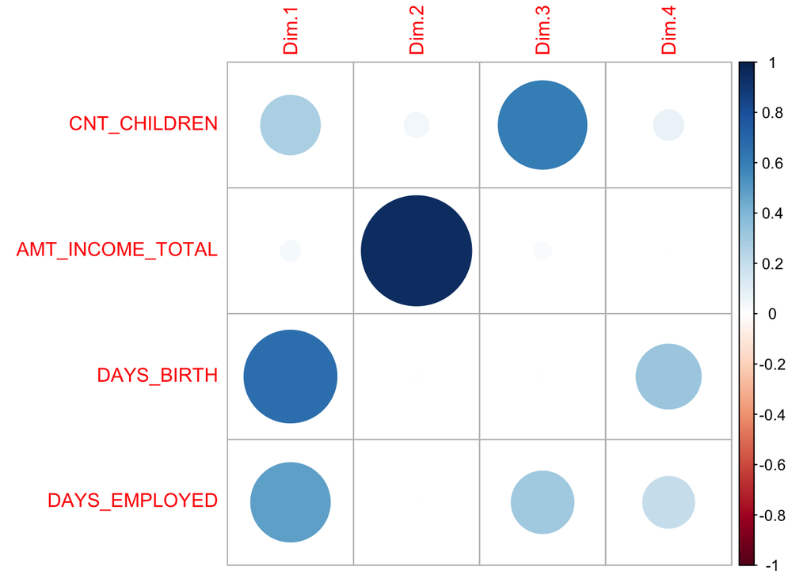

```r
corrplot(var$cos2, is.corre=FALSE)
```

No obstante, con la función fviz_cos2() se puede armar un diagrama de barras de variables “cos2”:

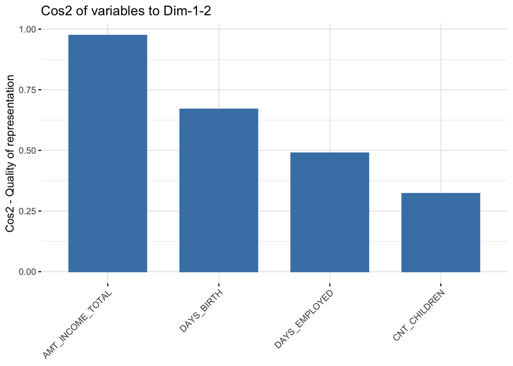

```r
fviz_cos2(pca.acc_scale, choice = "var", axes = 1:2)
```

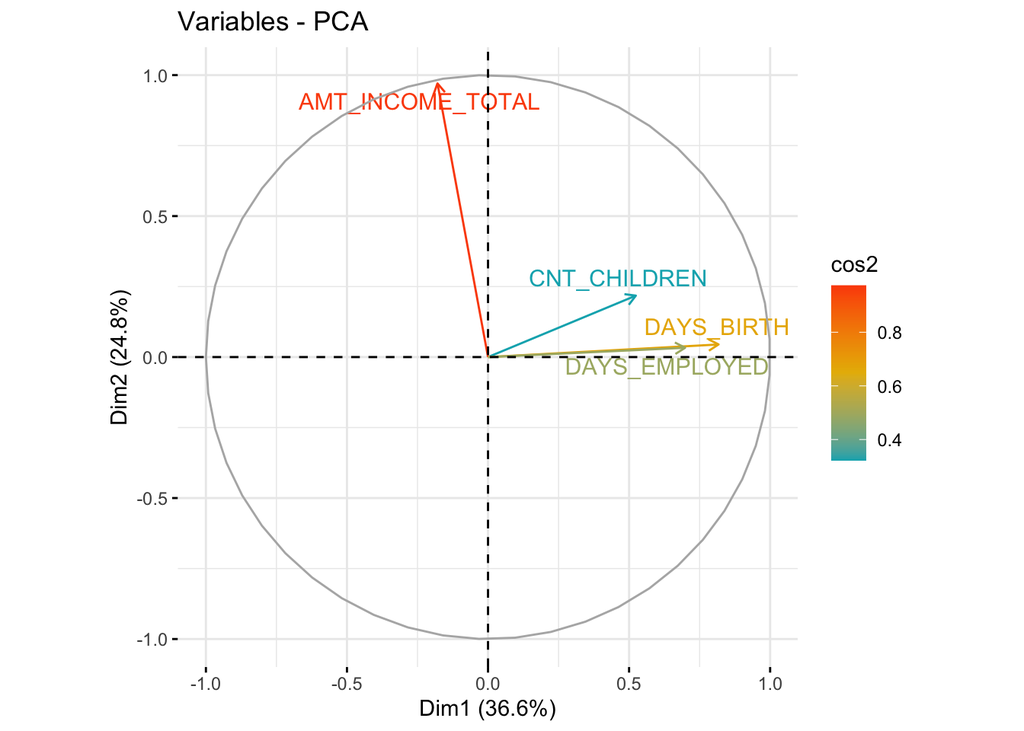

```r
fviz_pca_var(pca.acc_scale,
col.var = "cos2",
gradient.cols = c("#00AFBB", "#E7B800", "#FC4E07"),
repel = TRUE
)
```

Ahora se estudia la contribución.

```r
head(var$contrib,11)
```

```
##                      Dim.1      Dim.2      Dim.3      Dim.4
## CNT_CHILDREN     18.773051  4.7843173 64.7189777 11.7236544
## AMT_INCOME_TOTAL  2.195415 94.9030703  2.5063132  0.3952019
## DAYS_BIRTH       45.661748  0.2028645  0.4125115 53.7228763
## DAYS_EMPLOYED    33.369787  0.1097479 32.3621976 34.1582673
```

Como se puede observar para la Dim.2 la variable “AMT_INCOME_TOTAL” contribuye sustancialmente con un 94.9030703%, seguida de la Dim.3 para la variable “CNT_CHILDREN” con una contribución del 64.7189777% que a su vez es seguida por una contribución del 53.7228763% por parte de la Dim.4 para la variable “DAYS_BIRTH”. Cuando más grande sea el valor de la contribución, más contribución habrá al componente.

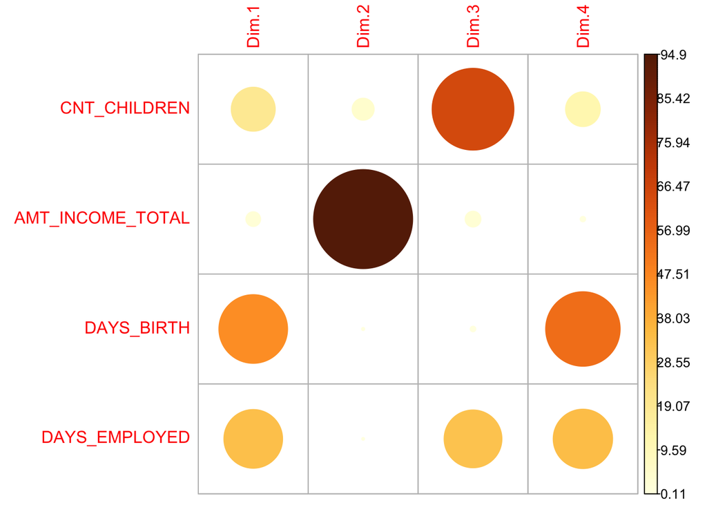

```r
corrplot(var$contrib[,1:4], is.cor=FALSE)
```

Finalmente, las variables que más contribuyen, se pueden resaltar en la gráfica de correlación de la siguiente manera:

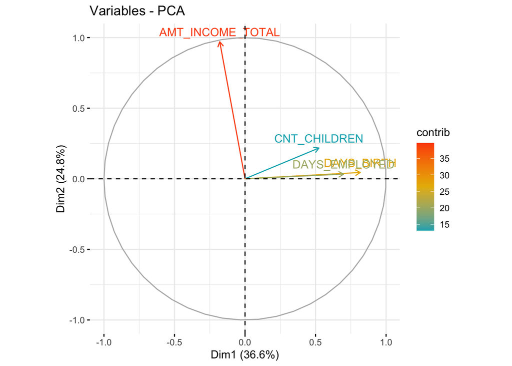

```r
fviz_pca_var(pca.acc_scale, col.var = "contrib",
gradient.cols = c("#00AFBB", "#E7B800", "#FC4E07")
)
```

## 3.6 Conclusiones

Esta práctica ha resultado ser una práctica muy interesante pero algo tediosa. Interesante, porque he tenido la oportunidad de estudiar de nuevo una base de datos nueva, que me ha permitido explorar nuevas relaciones entre variables, e implementar códigos más versátiles y eficientes. Ha sido muy entretenido haber explorado una base de datos nueva, y haberla tenido que limpiar y organizar, a fin de preparla para etapas posteriores del proyecto. No obstante, a pesar de que ha sido un proceso entretenido y lleno de detalles, la primera parte de la práctica me ha resultado un tanto complicada, pues me ha llevado mucho tiempo encontrar un *dataset* que cumpliese con todos los requisitos que se especifican en este enunciado y en el del campus virtual. Antes de escoger este *dataset* empecé a trabajar con uno que estaba relacionado con el alcohol y los estudiantes, pero lo tuvo que dejar porque a pesar de que cumplía con todos los requisitos en términos de tipos de variables, el *dataset* solo tenía 417 registros, por lo tanto no podía escoger ese. Despues de este primer *dataset* pasé a uno relacionado con el ámbito sanitario, más concretamente, a uno destinado a la detección de cancer de mama, pero a pesar de que este contaba con muchos registros, las variables eran mayoritariamente numéricas, y no había ninguna variable categórica ni binaria, por lo que tuve que emprender una nueva búsqueda, para finalmente escoger el *dataset* que se estudia en esta PAC.

Como se ha podido ver en esta práctica, se ha tenido que llevar a cabo una purga considerable, en cuanto a valores vacíos, y registros duplicados. La parte de eliminación de duplicados ha sido difícil, ya que el código inicial no funcionaba correctamente, no obstante, este me ha permitido purgar significativamente el *dataset* algo que definitivamente ayudará en términos de ruido y rápidez de aprendizaje, a la hora de aplicar el modelo deseado.

Además mediante el estudio estadístico de gran parte de las variables así como la relación entre algunas de ellas, nos ha permitido calcular la correlación, pudiendo detectar aquellas variables altamente relacionadas para luego eliminar una de ellas, tal y como se ha hecho. La razón de esta eliminación, reside en el objetivo de eliminar cualquier ruido posible en el juego de datos, pues si dos variables ofrecen casi la misma información, mantener las dos solo dificulta la tarea del modelo predictivo que se quiere aplicar en el juego de datos, y por ello, si hay variables que no aportan información adicional significativa, estas han de ser eliminadas. La representación de la matriz de dispersión y de nuevo, la scorrelaciones entre variables, nos han permitido ganar numerosos *insights* en cuanto a dependencias, a veces, incluso mostrando un comportamiento no esperado, como el de la relación inversamente proporcional entre el número de días contratado y la cantidad de hijos/ cantidad de familia, que mostraba como el número de hijos/ familiares aumentaba según el número de días empleado disminuía.

En referencia a la discretización de las tres variables seleccionadas, se ha podido contemplar la efictividad que tiene la fución “discretize(·)” para distinguir 3 rangos de valores en tres variables con una gran varianza. Además, los tres grupos que se han creado, abarcan un intervalo, que desde el punto de vista del objetivo analítico del proyecto, es importante, puesto que, en el caso de la variable “AMT_INCOME_TOTAL” resulta de gran importancia conocer antes que todo, el salario de una persona antes de indagar más acerca de su información personal, para estudiar si es apto o no para tener una tarjeta de crédito en propiedad.

Respecto al estudio de las componentes principales, i.e., PCA, se ha obtenido la medida relacionada con la asociación mutua entre las 4 variables iniciales, que viene a ser su matriz de covarianza asociada. Además, este estudio ha arrojado información sobre la dirección de dispersión de los datos. Y se ha podido comprobar como de 4 componentes principales, solo 1 cumplía con el criterio de Káiser.

En definitiva, hemos limpiado considerablemente el juego de datos, se han extraído relaciones muy interesantes, hemos podido facilitarle el futuro aprendizaje al modelo de clasificación, identificando intervalos sólidos y correctos. Y por último, el estudio PCA ha demostrado ser una herramienta útil para estudiar el impacto y las estadísticas de una variable respecto al resto de datos. Además, este estudio ha demostrado que las variables que mejor representadas están, son: “AMT_INCOME_TOTAL” y “DAYS_BIRTH”. Es por ello, que “AMT_INCOME_TOTAL” se coloca cerca de la circunferencia del círculo de correlación.

El siguiente paso, consistirá en incluir la etiqueta de “apto” y “no apto” en el *dataset* (a modo de variable binaria) que hemos procesado en este estudio, a partir del otro *dataset* mencionado antes, y que tiene el histórico bancario de los candidatos.

# 4 Referencias y bibliografía

- [Página web del dataset: Credit card approval](https://www.kaggle.com/datasets/rikdifos/credit-card-approval-prediction?select=application_record.csv)
- [Foro de la página web del dataset: Credit card approval](https://www.kaggle.com/datasets/rikdifos/credit-card-approval-prediction/discussion/119320)
- [Ventajas y desventajas de una tarjeta de crédito](https://saberespoder.com/articles/finance/beneficios-de-las-tarjetas-de-credito)
- [Para eliminar las filas con carácteres vacíos](https://www.geeksforgeeks.org/remove-rows-with-empty-cells-in-r/)